# FE621 Homework 3

## Problem 1 Finite Different Method

Partial differential equations: \begin{align} \frac{\partial{u}}{\partial{t}} (x,t) + \mu(x,t) \frac{\partial{u}}{\partial{x}}(x,t) + \frac{1}{2} \sigma^2 (x,t) \frac{\partial^2{u}}{\partial{x}^2} (x,t) - r(x,t) u(x,t) = 0 \end{align}

where

\begin{align} \mu(x,t) &= rx\\ \sigma(x,t) &= \sigma x\\ r(x,t) &= r \end{align}

The above PDE can be derived from arbitrage free pricing theory using a portfolio constructed by option and underlying asset. It can be also be directly obtained by applying Feyman-Kac theorem to the conditional expectation of option pricing.

Terminal Condition: \begin{align} call&: u(x,T) = (x - K)^+\\ put&: u(x,T) = (K-x)^+ \end{align}

Boundary Condition:

a) for European options, boundary conditions are applied for zero stock price $S = 0$ and infinite stock price $S \rightarrow \infty$

call option: \begin{align} u(0,t) &= 0\\ u(x,t) &= x, \quad x \rightarrow \infty \end{align}

put option:

\begin{align} u(0,t) &= K e^{-r (T-t)}\\ u(x,t) &= 0, \quad x \rightarrow \infty \end{align}

b) for American options, free boundary conditions are

call option: \begin{align} u(0,t) &= 0\\ u(S_f(t),t) &= S_f(t) - K\\ \frac{\partial{u}}{\partial{x}}(S_f(t),t) &= 1\\ u(x,t) &= x, \quad x \rightarrow \infty \end{align}

put option: \begin{align} u(0,t) &= K e^{-r (T-t)}\\ u(S_f(t),t) &= K - S_f(t)\\ \frac{\partial{u}}{\partial{x}}(S_f(t),t) &= -1\\ u(x,t) &= 0, \quad x \rightarrow \infty \end{align}

### 1.1 Explicit Finite Differences Method for Option Valuation includes Call and Puts / American and European

```python
import math
import numpy as np
import pandas as pd
import xlwings as xw
import scipy as sp
from scipy import stats
import matplotlib as plt
```

```python
T = 1  #Time to Expiry in Years
E = 100  #Strike
r = .05  #Risk Free Rate
SIGMA = .20  #Volatility
Type = False   #Type of Option True=Call False=Put
Ex = False #Early Exercise True=Yes  False=No
NAS = 40  #Number of Asset Steps - Higher is more accurate, but more time consuming

ds = 2 * E / NAS  #Asset Value Step Size
dt = (0.9/NAS/NAS/SIGMA/SIGMA)  #Time Step Size
NTS = int(T / dt) + 1  #Number of Time Steps
dt = T / NTS #Time Step Size
print("Asset Step Size %.2f Time Step Size %.2f Number of Time Steps %.2f Number of Asset Steps %.2f" %(ds, dt, NTS, NAS))
```

```
Asset Step Size 5.00 Time Step Size 0.01 Number of Time Steps 72.00 Number of Asset Steps 40.00
```

```python
#Setup Empty numpy Arrays
value_matrix = np.zeros((int(NAS+1), int(NTS)))
asset_price = np.arange(NAS*ds,-1,-ds)
```

```python
#Evaluate Terminal Value for Calls or Puts
if Type == True:
    value_matrix[:,-1]= np.maximum(asset_price - E,0)
else:
    value_matrix[:,-1]= np.maximum(E - asset_price,0)
```

```python
#Set Lower Boundry in Grid
for x in range(1,NTS):
    value_matrix[-1,-x-1] = value_matrix[-1,-x]* math.exp(-r*dt)
```

```python
#Set Mid and Ceiling Values in Grid
for x in range(1,int(NTS)):

    for y in range(1,int(NAS)):
        #Evaluate Option Greeks
        Delta = (value_matrix[y-1,-x] - value_matrix[y+1,-x]) / 2 / ds
        Gamma = (value_matrix[y-1,-x] - (2 * value_matrix[y,-x]) + value_matrix[y+1,-x]) / ds / ds
        Theta = (-.5 * SIGMA**2 * asset_price[y]**2 * Gamma) - (r * asset_price[y] * Delta) + (r * value_matrix[y,-x])

        #Set Mid Values
        value_matrix[y,-x-1] = value_matrix[y,-x] - Theta * dt
        if Ex == True:
            value_matrix[y,-x-1] = np.maximum(value_matrix[y,-x-1], value_matrix[y,-1])


        #Set Ceiling Value
        value_matrix[0,-x-1] = 2 * value_matrix[1,-x-1] - value_matrix[2,-x-1]

#Export Value Grid to Excel via xlWings
xw.view(value_matrix)
```

```python
#Option Valuation Profile in pandas - Index is Strike Price, column 0 is the option price
value_df = pd.DataFrame(value_matrix)
value_df = value_df.set_index(asset_price)

#Export Value Grid to Excel via xlWings
xw.view(value_df)
```

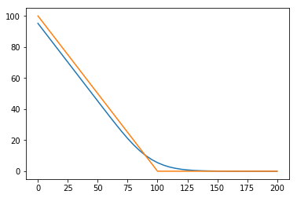

```python
%matplotlib inline
#Payoff Plot
plot_df = value_df.sort_index(ascending=True)
# print(plot_df.head())
plot_df[0].plot()
plot_df[NTS-1].plot()
```

Calculation of Option Value using BSM for Comparison - Works for European Options Only

```python
'''BSM VANILLA EUROPEAN OPTION VALUE CALCULATION'''
def bsm_option_value(S0, E, T, R, SIGMA):
    S0 = float(S0)
    d1 = (math.log(S0/E)+(R+(0.5*SIGMA**2))*T)/(SIGMA*math.sqrt(T))
    d2 = d1-(SIGMA*math.sqrt(T))
    call_value = S0*stats.norm.cdf(d1,0,1) - E*math.exp(-R*T)*stats.norm.cdf(d2,0,1)
    delta_call = stats.norm.cdf(d1,0,1)
    gamma_call = stats.norm.pdf(d1,0,1)/(S0*SIGMA*math.sqrt(T))
    theta_call = -(R*E*math.exp(-R*T)*stats.norm.cdf(d2,0,1))-(SIGMA*S0*stats.norm.pdf(d1,0,1)/(2*math.sqrt(T)))
    rho_call = T*E*math.exp(-R*T)*stats.norm.cdf(d2,0,1)
    vega_call = math.sqrt(T)*S0*stats.norm.pdf(d1,0,1)

    put_value =  E*math.exp(-R*T)*stats.norm.cdf(-d2,0,1) - (S0*stats.norm.cdf(-d1,0,1))
    delta_put = -stats.norm.cdf(-d1,0,1)
    gamma_put = stats.norm.pdf(d1,0,1)/(S0*SIGMA*math.sqrt(T))
    theta_put = (R*E*math.exp(-R*T)*stats.norm.cdf(-d2,0,1))-(SIGMA*S0*stats.norm.pdf(d1,0,1)/(2*math.sqrt(T)))
    rho_put = -T*E*math.exp(-R*T)*stats.norm.cdf(-d2,0,1)
    vega_put = math.sqrt(T)*S0*stats.norm.pdf(d1,0,1)

    return call_value, delta_call, gamma_call, theta_call, rho_call, vega_call, put_value, delta_put, gamma_put, theta_put, rho_put, vega_put
```

```python
#Run BSM Calculation for values and greeks
S0 = 100  #Current Value
R=r
#BSM function call and output assignment
call_value, delta_call, gamma_call, theta_call, rho_call, vega_call, put_value, delta_put, gamma_put, theta_put, rho_put, vega_put = bsm_option_value(S0, E, T, R, SIGMA)

if Type == False:
    BSM_val = put_value
if Type == True:
    BSM_val = call_value
print(BSM_val)
```

```
5.57352602226
```

```python
#Finite Differences Method Value at S0
fd_value = value_df.ix[S0,1]
print(fd_value)
```

```
5.47684205529
```

```python
#Difference
diff = put_value - fd_value
print("Nominal Difference is %.4f" %diff)

pct_diff = abs(diff / put_value)
print("Percent Difference is {percent:.4%}".format(percent=pct_diff))

#If you want higher accuracy you can increase the number of asset steps
```

```
Nominal Difference is 0.0967
Percent Difference is 1.7347%
```

### 1.2 Implicit Finite Differences Method for Option Valuation includes Call and Puts /American and European

Implicit equations: $$ a(x_{i-1},t_j) u(x_{i-1},t_j) + b(x_{i},t_j) u(x_{i},t_j)+c(x_{i+1},t_j) u(x_{i+1},t_j) = u(x_{i},t_{j+1}) $$ where \begin{align} a(x,t) &= (\frac{\mu(x,t)}{2 dx} - \frac{\sigma^2(x,t)}{2dx^2})dt = \frac{dt S}{2 dx}(r - \frac{\sigma^2 x}{dx})\\ b(x,t) &= 1 + r dt + \frac{\sigma^2(x,t) dt}{dx^2} = 1+ r dt + \frac{\sigma^2 x^2}{dx^2}dt\\ c(x,t) &= -(\frac{\mu(x,t)}{2dx} + \frac{\sigma^2(x,t)}{2dx^2})dt = -\frac{dt x}{2 dx}(r+\frac{\sigma^2 x}{dx}) \end{align} for $i=1,2,\cdots , n-1$

As there are n-1 unkown variables and n-1 uncorrelated equations, we can solve the following linear algebra backwards.

\begin{align} \begin{bmatrix} b(x_1) & c(x_1) & 0 & \cdots & \cdots & 0&0\\ a(x_2) & b(x_2) & c(x_2) & 0 & \cdots & 0&0\\ 0 & a(x_3) & b(x_3) & c(x_3) & \cdots & 0&0\\ \vdots &\vdots&\vdots&\vdots&\vdots&\vdots&\vdots\\ 0&0&0&0&\cdots&a(x_{n-1})&b(x_{n-1}) \end{bmatrix} \begin{bmatrix} u(x_1,t_j)\\ u(x_2,t_j)\\ u(x_3,t_j)\\ \vdots\\ u(x_{n-1},t_j) \end{bmatrix}= \begin{bmatrix} u(x_1,t_{j+1}) - a(x_1,t_j)u(x_0,t_j)\\ u(x_2,t_{j+1})\\ u(x_3,t_{j+1})\\ \vdots\\ u(x_{n-1},t_{j+1}) - c(x_{n-1},t_j)u(x_n,t_j) \end{bmatrix} \end{align}

```python
T = 1  #Time to Expiry in Years
E = 100  #Strike
r = .05  #Risk Free Rate
SIGMA = .20  #Volatility
Type = False   #Type of Option True=Call False=Put
Ex = False #Early Exercise True=Yes  False=No
NAS = 40  #Number of Asset Steps - Higher is more accurate, but more time consuming

ds = 2 * E / NAS  #Asset Value Step Size
dt = (0.9/NAS/NAS/SIGMA/SIGMA)  #Time Step Size
NTS = int(T / dt) + 1  #Number of Time Steps
dt = T / NTS #Time Step Size
print("Asset Step Size %.2f Time Step Size %.2f Number of Time Steps %.2f Number of Asset Steps %.2f" %(ds, dt, NTS, NAS))
```

```
Asset Step Size 5.00 Time Step Size 0.01 Number of Time Steps 72.00 Number of Asset Steps 40.00
```

```python
#Setup Empty numpy Arrays
value_matrix = np.zeros((int(NAS+1), int(NTS)))
asset_price = np.arange(NAS*ds,-1,-ds)
```

```python
value_matrix.shape
```

```
(41, 72)
```

```python
#Evaluate Terminal Value for Calls or Puts
if Type == True:
    value_matrix[:,-1]= np.maximum(asset_price - E,0)
    #Set Lower Boundry in Grid
    for x in range(1,NTS):
        value_matrix[-1,-x-1] = 0
        value_matrix[0,-x-1] = asset_price[0] - E*math.exp(-r*dt*x)
else:
    value_matrix[:,-1]= np.maximum(E - asset_price,0)
    #Set Lower Boundry in Grid
    for x in range(1,NTS):
        value_matrix[-1,-x-1] = value_matrix[-1,-x]* math.exp(-r*dt)
        value_matrix[0,-x-1] = 0
```

```python
a = lambda x: (r*x/2/ds - (SIGMA*x)**2/2/ds**2)*dt
b = lambda x: 1 + r*dt + (SIGMA*x)**2*dt/ds**2
c = lambda x: -(r*x/2/ds + (SIGMA*x)**2/2/ds**2)*dt
```

```python
a_entries = a(asset_price[1:-2])
b_entries = b(asset_price[1:-1])
c_entries = c(asset_price[2:-1])
```

```python
A = np.diag(a_entries,1) + np.diag(b_entries) + np.diag(c_entries,-1)
```

```python
#Set Mid and Ceiling Values in Grid
for x in range(1,int(NTS)):
    d =  value_matrix[1:-1,-x]
    d[0] -= c(asset_price[1]) * value_matrix[0,-x-1]
    d[-1] -= a(asset_price[-2]) * value_matrix[-1,-x-1]
    value_matrix[1:-1,-x-1] = np.linalg.solve(A,d)
#     break
#Export Value Grid to Excel via xlWings
xw.view(value_matrix)
```

```python
#Option Valuation Profile in pandas - Index is Strike Price, column 0 is the option price
value_df = pd.DataFrame(value_matrix)
value_df = value_df.set_index(asset_price)

#Export Value Grid to Excel via xlWings
xw.view(value_df)
```

```python
'''BSM VANILLA EUROPEAN OPTION VALUE CALCULATION'''
def bsm_option_value(S0, E, T, R, SIGMA):
    S0 = float(S0)
    d1 = (math.log(S0/E)+(R+(0.5*SIGMA**2))*T)/(SIGMA*math.sqrt(T))
    d2 = d1-(SIGMA*math.sqrt(T))
    call_value = S0*stats.norm.cdf(d1,0,1) - E*math.exp(-R*T)*stats.norm.cdf(d2,0,1)
    delta_call = stats.norm.cdf(d1,0,1)
    gamma_call = stats.norm.pdf(d1,0,1)/(S0*SIGMA*math.sqrt(T))
    theta_call = -(R*E*math.exp(-R*T)*stats.norm.cdf(d2,0,1))-(SIGMA*S0*stats.norm.pdf(d1,0,1)/(2*math.sqrt(T)))
    rho_call = T*E*math.exp(-R*T)*stats.norm.cdf(d2,0,1)
    vega_call = math.sqrt(T)*S0*stats.norm.pdf(d1,0,1)

    put_value =  E*math.exp(-R*T)*stats.norm.cdf(-d2,0,1) - (S0*stats.norm.cdf(-d1,0,1))
    delta_put = -stats.norm.cdf(-d1,0,1)
    gamma_put = stats.norm.pdf(d1,0,1)/(S0*SIGMA*math.sqrt(T))
    theta_put = (R*E*math.exp(-R*T)*stats.norm.cdf(-d2,0,1))-(SIGMA*S0*stats.norm.pdf(d1,0,1)/(2*math.sqrt(T)))
    rho_put = -T*E*math.exp(-R*T)*stats.norm.cdf(-d2,0,1)
    vega_put = math.sqrt(T)*S0*stats.norm.pdf(d1,0,1)

    return call_value, delta_call, gamma_call, theta_call, rho_call, vega_call, put_value, delta_put, gamma_put, theta_put, rho_put, vega_put
#Run BSM Calculation for values and greeks
S0 = 100  #Current Value
R=r
#BSM function call and output assignment
call_value, delta_call, gamma_call, theta_call, rho_call, vega_call, put_value, delta_put, gamma_put, theta_put, rho_put, vega_put = bsm_option_value(S0, E, T, R, SIGMA)

if Type == False:
    BSM_val = put_value
if Type == True:
    BSM_val = call_value
print(BSM_val)
```

```
5.573526022256971
```

```python
#Finite Differences Method Value at S0
fd_value = value_df.ix[S0,1]
print(fd_value)
#Difference
diff = put_value - fd_value
print("Nominal Difference is %.4f" %diff)

pct_diff = abs(diff / put_value)
print("Percent Difference is {percent:.4%}".format(percent=pct_diff))

#If you want higher accuracy you can increase the number of asset steps
```

```
5.449841724610092
Nominal Difference is 0.1237
Percent Difference is 2.2191%
```

### 1.3 For both the Explicit and Implicit Finite Difference schemes estimate the numbers $\Delta t$, $\Delta x$ as well as the total number Nj of points on the space grid x to obtain a desired error of $\epsilon = 0.001$. Hint. You need to do this part in a theoretical way. Please use the convergence order as the actual error of the estimate.

Using the convergence condition for trinomial tree $$\Delta x \geq \sigma \sqrt{3 \Delta t}$$

The convergence rate of both explicit and implicit FDM is $$O(\Delta t + \Delta x ^2)$$

### 1.4 Consider S0 = 100;K = 100, T = 1 year, $\sigma$ = 25%; r = 6%; $\delta = 0.03$. Calculate and report the price for European Call and Put using both explicit and implicit FD methods and the number of steps that you calculated in the previous point (part c).

```python
T = 1  #Time to Expiry in Years
E = 100  #Strike
r = .06  #Risk Free Rate
SIGMA = .25  #Volatility
Type = False   #Type of Option True=Call False=Put
Ex = False #Early Exercise True=Yes  False=No

# ds = 0.1
# dt = 0.1

# NAS = math.ceil(2*E/ds)
# NTS = math.ceil(T/dt) + 1

# ds = 2.*E/NAS
# dt = 1.*T/NTS



NAS = 200  #Number of Asset Steps - Higher is more accurate, but more time consuming
ds = 2 * E / NAS  #Asset Value Step Size
dt = (0.9/NAS/NAS/SIGMA/SIGMA)  #Time Step Size
NTS = int(T / dt) + 1  #Number of Time Steps
dt = T / NTS #Time Step Size


print("Asset Step Size %.2f Time Step Size %.2f Number of Time Steps %.2f Number of Asset Steps %.2f" %(ds, dt, NTS, NAS))

#Setup Empty numpy Arrays
value_matrix = np.zeros((int(NAS+1), int(NTS)))
asset_price = np.arange(NAS*ds,0-1e-6,-ds)
# print(asset_price.shape)

#Evaluate Terminal Value for Calls or Puts
if Type == True:
    value_matrix[:,-1]= np.maximum(asset_price - E,0)
else:
    value_matrix[:,-1]= np.maximum(E - asset_price,0)

#Set Lower Boundry in Grid
for x in range(1,NTS):
    value_matrix[-1,-x-1] = value_matrix[-1,-x]* math.exp(-r*dt)

#Set Mid and Ceiling Values in Grid
for x in range(1,int(NTS)):

    for y in range(1,int(NAS)):
        #Evaluate Option Greeks
        Delta = (value_matrix[y-1,-x] - value_matrix[y+1,-x]) / 2 / ds
        Gamma = (value_matrix[y-1,-x] - (2 * value_matrix[y,-x]) + value_matrix[y+1,-x]) / ds / ds
        Theta = (-.5 * SIGMA**2 * asset_price[y]**2 * Gamma) - (r * asset_price[y] * Delta) + (r * value_matrix[y,-x])

        #Set Mid Values
        value_matrix[y,-x-1] = value_matrix[y,-x] - Theta * dt
        if Ex == True:
            value_matrix[y,-x-1] = np.maximum(value_matrix[y,-x-1], value_matrix[y,-1])


        #Set Ceiling Value
        value_matrix[0,-x-1] = 2 * value_matrix[1,-x-1] - value_matrix[2,-x-1]

#Option Valuation Profile in pandas - Index is Strike Price, column 0 is the option price
value_df = pd.DataFrame(value_matrix)
value_df = value_df.set_index(asset_price)

#Export Value Grid to Excel via xlWings
# xw.view(value_df)

#Run BSM Calculation for values and greeks
S0 = 100  #Current Value
R=r
#BSM function call and output assignment
call_value, delta_call, gamma_call, theta_call, rho_call, vega_call, put_value, delta_put, gamma_put, theta_put, rho_put, vega_put = bsm_option_value(S0, E, T, R, SIGMA)

if Type == False:
    BSM_val = put_value
if Type == True:
    BSM_val = call_value
print(BSM_val)

#Finite Differences Method Value at S0
fd_value = value_df.ix[S0,1]
print(fd_value)

#Difference
diff = put_value - fd_value
print("Nominal Difference is %.4f" %diff)

pct_diff = abs(diff / put_value)
print("Percent Difference is {percent:.4%}".format(percent=pct_diff))

#If you want higher accuracy you can increase the number of asset steps
```

```
Asset Step Size 1.00 Time Step Size 0.00 Number of Time Steps 2778.00 Number of Asset Steps 200.00
7.021499520147614
7.018465726378327
Nominal Difference is 0.0030
Percent Difference is 0.0432%
```

### Repeat part (c) of this problem but this time get the empirical number of iterations. Specifically, obtain the Black Scholes price for the data in (d), then do an iterative procedure to figure out the $\Delta x$, $\Delta t$, N, and Nj to obtain an accuracy of $\epsilon = 0.001$.

```python
def optionPrice_explicit_FDM(E=100,T=1,r=.06,sigma=0.25,isAmerican=False,isCall=True,NAS=100):
    isExplicit = True
    SIGMA = sigma  #Volatility
    Type = isCall   #Type of Option True=Call False=Put
    Ex = isAmerican #Early Exercise True=Yes  False=No

    ds = 2 * E / NAS  #Asset Value Step Size
    dt = (1/NAS/NAS/SIGMA/SIGMA)  #Time Step Size
    NTS = int(T / dt) + 1  #Number of Time Steps
    dt = T / NTS #Time Step Size
    # ds = 0.1
    # dt = 0.1

    # NAS = math.ceil(2*E/ds)
    # NTS = math.ceil(T/dt) + 1

#     dt = T/NTS


#     NAS = 200  #Number of Asset Steps - Higher is more accurate, but more time consuming
#     ds = 2 * E / NAS  #Asset Value Step Size
#     dt = (0.9/NAS/NAS/SIGMA/SIGMA)  #Time Step Size
#     NTS = int(T / dt) + 1  #Number of Time Steps
#     dt = T / NTS #Time Step Size


    print("Asset Step Size %.2f Time Step Size %.2f Number of Time Steps %.2f Number of Asset Steps %.2f" %(ds, dt, NTS, NAS))

    #Setup Empty numpy Arrays
    value_matrix = np.zeros((int(NAS+1), int(NTS)))
    asset_price = np.arange(NAS*ds,0-1e-6,-ds)
    # print(asset_price.shape)
    if isExplicit==True:

        #Evaluate Terminal Value for Calls or Puts
        if Type == True:
            value_matrix[:,-1]= np.maximum(asset_price - E,0)
        else:
            value_matrix[:,-1]= np.maximum(E - asset_price,0)

        #Set Lower Boundry in Grid
        for x in range(1,NTS):
            value_matrix[-1,-x-1] = value_matrix[-1,-x]* math.exp(-r*dt)

        #Set Mid and Ceiling Values in Grid
        for x in range(1,int(NTS)):

            for y in range(1,int(NAS)):
                #Evaluate Option Greeks
                Delta = (value_matrix[y-1,-x] - value_matrix[y+1,-x]) / 2 / ds
                Gamma = (value_matrix[y-1,-x] - (2 * value_matrix[y,-x]) + value_matrix[y+1,-x]) / ds / ds
                Theta = (-.5 * SIGMA**2 * asset_price[y]**2 * Gamma) - (r * asset_price[y] * Delta) + (r * value_matrix[y,-x])

                #Set Mid Values
                value_matrix[y,-x-1] = value_matrix[y,-x] - Theta * dt
                if Ex == True:
                    value_matrix[y,-x-1] = np.maximum(value_matrix[y,-x-1], value_matrix[y,-1])


                #Set Ceiling Value
                value_matrix[0,-x-1] = 2 * value_matrix[1,-x-1] - value_matrix[2,-x-1]
    else:
        #Evaluate Terminal Value for Calls or Puts
        if Type == True:
            value_matrix[:,-1]= np.maximum(asset_price - E,0)
            #Set Lower Boundry in Grid
            for x in range(1,NTS):
                value_matrix[-1,-x-1] = 0
                value_matrix[0,-x-1] = asset_price[0] - E*math.exp(-r*dt*x)
        else:
            value_matrix[:,-1]= np.maximum(E - asset_price,0)
            #Set Lower Boundry in Grid
            for x in range(1,NTS):
                value_matrix[-1,-x-1] = value_matrix[-1,-x]* math.exp(-r*dt)
                value_matrix[0,-x-1] = 0
        a = lambda x: (r*x/2/ds - (SIGMA*x)**2/2/ds**2)*dt
        b = lambda x: 1 + r*dt + (SIGMA*x)**2*dt/ds**2
        c = lambda x: -(r*x/2/ds + (SIGMA*x)**2/2/ds**2)*dt
        a_entries = a(asset_price[1:-2])
        b_entries = b(asset_price[1:-1])
        c_entries = c(asset_price[2:-1])
        A = np.diag(a_entries,1) + np.diag(b_entries) + np.diag(c_entries,-1)
        #Set Mid and Ceiling Values in Grid
        for x in range(1,int(NTS)):
            d =  value_matrix[1:-1,-x]
            d[0] -= c(asset_price[1]) * value_matrix[0,-x-1]
            d[-1] -= a(asset_price[-2]) * value_matrix[-1,-x-1]
            value_matrix[1:-1,-x-1] = np.linalg.solve(A,d)

    #Option Valuation Profile in pandas - Index is Strike Price, column 0 is the option price
    value_df = pd.DataFrame(value_matrix)
    value_df = value_df.set_index(asset_price)

    #Export Value Grid to Excel via xlWings
    # xw.view(value_df)

    #Run BSM Calculation for values and greeks
    S0 = 100  #Current Value
    R=r
    #BSM function call and output assignment
    call_value, delta_call, gamma_call, theta_call, rho_call, vega_call, put_value, delta_put, gamma_put, theta_put, rho_put, vega_put = bsm_option_value(S0, E, T, R, SIGMA)

    if Type == False:
        BSM_val = put_value
    if Type == True:
        BSM_val = call_value
    print("Black-Scholes value: {}".format(BSM_val))

    #Finite Differences Method Value at S0
    fd_value = value_df.ix[S0,1]
    print("finite difference value: {}".format(fd_value))

    #Difference
    diff = BSM_val - fd_value
    print("Nominal Difference is %.4f" %diff)

    pct_diff = abs(diff / BSM_val)
    print("Percent Difference is {percent:.4%}".format(percent=pct_diff))
```

```python
optionPrice_explicit_FDM(NAS=100)
```

```
Asset Step Size 2.00 Time Step Size 0.00 Number of Time Steps 626.00 Number of Asset Steps 100.00
Black-Scholes value: 12.845046161722756
finite difference value: 12.814631285571515
Nominal Difference is 0.0304
Percent Difference is 0.2368%
```

This is a Demo about parameters choosing. Same as part (b), we firstly choose NAS and then, use our empirical formula to determine the other parameters. Limited by the computer, we only showed the case where NAS in $(2^0, 2^1, 2^2)\times 100$

```python
for NAS in [100,200,400]:
    optionPrice_explicit_FDM(NAS=NAS)
```

```
Asset Step Size 2.00 Time Step Size 0.00 Number of Time Steps 626.00 Number of Asset Steps 100.00
Black-Scholes value: 12.845046161722756
finite difference value: 12.814631285571515
Nominal Difference is 0.0304
Percent Difference is 0.2368%
Asset Step Size 1.00 Time Step Size 0.00 Number of Time Steps 2501.00 Number of Asset Steps 200.00
```

```
Black-Scholes value: 12.845046161722756
finite difference value: 12.837440883931219
Nominal Difference is 0.0076
Percent Difference is 0.0592%
Asset Step Size 0.50 Time Step Size 0.00 Number of Time Steps 10001.00 Number of Asset Steps 400.00
Black-Scholes value: 12.845046161722756
finite difference value: 12.84314469605975
Nominal Difference is 0.0019
Percent Difference is 0.0148%
```

We can see, by using the explicit finite difference method, as the NAS(number of the asset steps) growths, the nominal error decreases from 0.0304 to 0.0019. Thus if we chose $\epsilon=0.002$, we have $$ N_s = 400\\ N_t = 10001\\ ds = 0.5\\ dt = 1e-4 $$

For implicit method, we don't need to fit ds and dt correspondingly as there is no need to worry about the convergency

```python
def optionPrice_implicit_FDM(E=100,T=1,r=.06,sigma=0.25,isAmerican=False,isCall=True,NAS=100,NTS=100):
    isExplicit = False
    SIGMA = sigma  #Volatility
    Type = isCall   #Type of Option True=Call False=Put
    Ex = isAmerican #Early Exercise True=Yes  False=No

    ds = 2 * E / NAS  #Asset Value Step Size
#     dt = (1/NAS/NAS/SIGMA/SIGMA)  #Time Step Size
#     NTS = int(T / dt) + 1  #Number of Time Steps
    dt = T / NTS #Time Step Size
    # ds = 0.1
    # dt = 0.1

    # NAS = math.ceil(2*E/ds)
    # NTS = math.ceil(T/dt) + 1

#     dt = T/NTS


#     NAS = 200  #Number of Asset Steps - Higher is more accurate, but more time consuming
#     ds = 2 * E / NAS  #Asset Value Step Size
#     dt = (0.9/NAS/NAS/SIGMA/SIGMA)  #Time Step Size
#     NTS = int(T / dt) + 1  #Number of Time Steps
#     dt = T / NTS #Time Step Size


    print("Asset Step Size %.2f Time Step Size %.2f Number of Time Steps %.2f Number of Asset Steps %.2f" %(ds, dt, NTS, NAS))

    #Setup Empty numpy Arrays
    value_matrix = np.zeros((int(NAS+1), int(NTS)))
    asset_price = np.arange(NAS*ds,0-1e-6,-ds)
    # print(asset_price.shape)
    if isExplicit==True:

        #Evaluate Terminal Value for Calls or Puts
        if Type == True:
            value_matrix[:,-1]= np.maximum(asset_price - E,0)
        else:
            value_matrix[:,-1]= np.maximum(E - asset_price,0)

        #Set Lower Boundry in Grid
        for x in range(1,NTS):
            value_matrix[-1,-x-1] = value_matrix[-1,-x]* math.exp(-r*dt)

        #Set Mid and Ceiling Values in Grid
        for x in range(1,int(NTS)):

            for y in range(1,int(NAS)):
                #Evaluate Option Greeks
                Delta = (value_matrix[y-1,-x] - value_matrix[y+1,-x]) / 2 / ds
                Gamma = (value_matrix[y-1,-x] - (2 * value_matrix[y,-x]) + value_matrix[y+1,-x]) / ds / ds
                Theta = (-.5 * SIGMA**2 * asset_price[y]**2 * Gamma) - (r * asset_price[y] * Delta) + (r * value_matrix[y,-x])

                #Set Mid Values
                value_matrix[y,-x-1] = value_matrix[y,-x] - Theta * dt
                if Ex == True:
                    value_matrix[y,-x-1] = np.maximum(value_matrix[y,-x-1], value_matrix[y,-1])


                #Set Ceiling Value
                value_matrix[0,-x-1] = 2 * value_matrix[1,-x-1] - value_matrix[2,-x-1]
    else:
        #Evaluate Terminal Value for Calls or Puts
        if Type == True:
            value_matrix[:,-1]= np.maximum(asset_price - E,0)
            #Set Lower Boundry in Grid
            for x in range(1,NTS):
                value_matrix[-1,-x-1] = 0
                value_matrix[0,-x-1] = asset_price[0] - E*math.exp(-r*dt*x)
        else:
            value_matrix[:,-1]= np.maximum(E - asset_price,0)
            #Set Lower Boundry in Grid
            for x in range(1,NTS):
                value_matrix[-1,-x-1] = value_matrix[-1,-x]* math.exp(-r*dt)
                value_matrix[0,-x-1] = 0
        a = lambda x: (r*x/2/ds - (SIGMA*x)**2/2/ds**2)*dt
        b = lambda x: 1 + r*dt + (SIGMA*x)**2*dt/ds**2
        c = lambda x: -(r*x/2/ds + (SIGMA*x)**2/2/ds**2)*dt
        a_entries = a(asset_price[1:-2])
        b_entries = b(asset_price[1:-1])
        c_entries = c(asset_price[2:-1])
        A = np.diag(a_entries,1) + np.diag(b_entries) + np.diag(c_entries,-1)
        #Set Mid and Ceiling Values in Grid
        for x in range(1,int(NTS)):
            d =  value_matrix[1:-1,-x]
            d[0] -= c(asset_price[1]) * value_matrix[0,-x-1]
            d[-1] -= a(asset_price[-2]) * value_matrix[-1,-x-1]
            value_matrix[1:-1,-x-1] = np.linalg.solve(A,d)

    #Option Valuation Profile in pandas - Index is Strike Price, column 0 is the option price
    value_df = pd.DataFrame(value_matrix)
    value_df = value_df.set_index(asset_price)

    #Export Value Grid to Excel via xlWings
    # xw.view(value_df)

    #Run BSM Calculation for values and greeks
    S0 = 100  #Current Value
    R=r
    #BSM function call and output assignment
    call_value, delta_call, gamma_call, theta_call, rho_call, vega_call, put_value, delta_put, gamma_put, theta_put, rho_put, vega_put = bsm_option_value(S0, E, T, R, SIGMA)

    if Type == False:
        BSM_val = put_value
    if Type == True:
        BSM_val = call_value
    print("Black-Scholes value: {}".format(BSM_val))

    #Finite Differences Method Value at S0
    fd_value = value_df.ix[S0,1]
    print("finite difference value: {}".format(fd_value))

    #Difference
    diff = BSM_val - fd_value
    print("Nominal Difference is %.4f" %diff)

    pct_diff = abs(diff / BSM_val)
    print("Percent Difference is {percent:.4%}".format(percent=pct_diff))
```

```python
for NAS in [100,200,400]:
    for NTS in [100,200,400]:
        optionPrice_implicit_FDM(NAS=NAS,NTS=NTS)
```

```
Asset Step Size 2.00 Time Step Size 0.01 Number of Time Steps 100.00 Number of Asset Steps 100.00
Black-Scholes value: 12.845046161722756
finite difference value: 12.668009064190441
Nominal Difference is 0.1770
Percent Difference is 1.3783%
Asset Step Size 2.00 Time Step Size 0.01 Number of Time Steps 200.00 Number of Asset Steps 100.00
Black-Scholes value: 12.845046161722756
finite difference value: 12.752793335437433
Nominal Difference is 0.0923
Percent Difference is 0.7182%
Asset Step Size 2.00 Time Step Size 0.00 Number of Time Steps 400.00 Number of Asset Steps 100.00
Black-Scholes value: 12.845046161722756
finite difference value: 12.795063236331348
Nominal Difference is 0.0500
Percent Difference is 0.3891%
Asset Step Size 1.00 Time Step Size 0.01 Number of Time Steps 100.00 Number of Asset Steps 200.00
Black-Scholes value: 12.845046161722756
finite difference value: 12.673942027783822
Nominal Difference is 0.1711
Percent Difference is 1.3321%
Asset Step Size 1.00 Time Step Size 0.01 Number of Time Steps 200.00 Number of Asset Steps 200.00
```

```
Black-Scholes value: 12.845046161722756
finite difference value: 12.758682821436373
Nominal Difference is 0.0864
Percent Difference is 0.6723%
Asset Step Size 1.00 Time Step Size 0.00 Number of Time Steps 400.00 Number of Asset Steps 200.00
Black-Scholes value: 12.845046161722756
finite difference value: 12.800931318457957
Nominal Difference is 0.0441
Percent Difference is 0.3434%
Asset Step Size 0.50 Time Step Size 0.01 Number of Time Steps 100.00 Number of Asset Steps 400.00
Black-Scholes value: 12.845046161722756
finite difference value: 12.675423600916142
Nominal Difference is 0.1696
Percent Difference is 1.3205%
Asset Step Size 0.50 Time Step Size 0.01 Number of Time Steps 200.00 Number of Asset Steps 400.00
Black-Scholes value: 12.845046161722756
finite difference value: 12.7601535684437
Nominal Difference is 0.0849
Percent Difference is 0.6609%
Asset Step Size 0.50 Time Step Size 0.00 Number of Time Steps 400.00 Number of Asset Steps 400.00
Black-Scholes value: 12.845046161722756
finite difference value: 12.802396735457219
Nominal Difference is 0.0426
Percent Difference is 0.3320%
```

### 1.6 Using the parameters from part (d), plot on the same graph the implicit finite difference probabilities pu; pm; pd as a function of $\sigma$, $\sigma \in \{0.05,0.1,0.15,\cdots,0.6\}$. Write detailed comments on your observations.

\begin{align} Pu + Pm + Pd = 1\\ Pu \Delta x - Pd \Delta x = \mu \Delta x\\ Pu \Delta x^2 + Pd \Delta x^2 - (\mu \Delta x)^2 = \sigma^2 \Delta t \end{align} where $$\mu = r - q - \frac{1}{2}\sigma^2$$ Solve the equations, we have \begin{align} Pu = p + \frac{\mu \Delta t}{2 \Delta x}\\ Pm = 1 - 2p\\ Pd = p - \frac{\mu \Delta t}{2 \Delta x} \end{align} where $$p = \frac{1}{2}\frac{(\mu \Delta t)^2 + (\sigma \sqrt{\Delta t})^2}{\Delta x^2}$$

Using the convergence condition in part (d), we obtain \begin{align} \Delta t = \frac{\epsilon}{1+3\sigma^2}\\ \Delta x = \sigma \sqrt{3 \Delta t} \end{align}

```python
def calculate_probs(eps,r,q,sigma):
    dt = eps/(1+3*sigma**2)
    dx = sigma*math.sqrt(3*dt)
    mu = r - q - .5*sigma**2
    p = .5*((mu*dt)**2+(sigma*math.sqrt(dt))**2)/dx**2
    pu = p + mu*dt/2/dx
    pd = p - mu*dt/2/dx
    pm = 1 - 2*p
    return pu,pm,pd
```

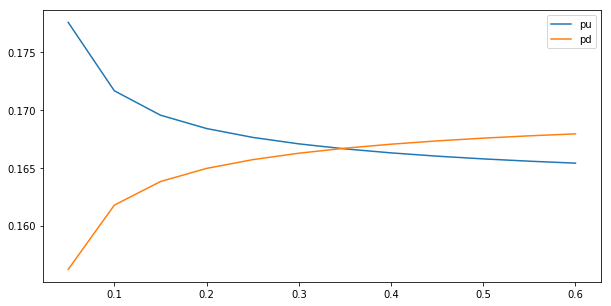

```python
pu_list = []
pm_list = []
pd_list = []
sigma_list = np.arange(0.05,0.605,0.05)
for sigma in np.arange(0.05,0.605,0.05):
    pu,pm,pd = calculate_probs(0.001,0.06,0,sigma)
    pu_list.append(pu)
    pm_list.append(pm)
    pd_list.append(pd)
plt.pyplot.figure(figsize=(10,5))
plt.pyplot.plot(sigma_list,pu_list)

# plt.pyplot.plot(sigma_list,pm_list)

plt.pyplot.plot(sigma_list,pd_list)

plt.pyplot.legend(["pu","pd"])
```

### 1.7 Implement the Crank-Nicolson Finite Difference method and price both European Call and Put options. Use the same parameters as in part (d) and the same number of steps in the grid. Put the results of the 3 methods (EFD, IFD, CNFD) side by side in a table and write your observations.

Similar to the implicit scheme, the only difference is the coefficients of the linear equations. See the following codes to see if I have any error especially a1,b1,c1,a2,b2,c2

```python
import pandas as pd

# Crank-Nicolson Scheme
def optionPrice_CN_FDM(E=100,T=1,r=.06,sigma=0.25,isAmerican=False,isCall=True,NAS=100,NTS=100):

    SIGMA = sigma  #Volatility
    Type = isCall   #Type of Option True=Call False=Put
    Ex = isAmerican #Early Exercise True=Yes  False=No

    ds = 2 * E / NAS  #Asset Value Step Size
    dt = T / NTS #Time Step Size


    print("Asset Step Size %.2f Time Step Size %.2f Number of Time Steps %.2f Number of Asset Steps %.2f" %(ds, dt, NTS, NAS))

    #Setup Empty numpy Arrays
    value_matrix = np.zeros((int(NAS+1), int(NTS)))
    asset_price = np.arange(NAS*ds,0-1e-6,-ds)
    # print(asset_price.shape)


    # Crank-Nicolson Scheme
    if Type == True:
        value_matrix[:,-1]= np.maximum(asset_price - E,0)
        #Set Lower Boundry in Grid
        for x in range(1,NTS):
            value_matrix[-1,-x-1] = 0
            value_matrix[0,-x-1] = asset_price[0]
    else:
        value_matrix[:,-1]= np.maximum(E - asset_price,0)
        #Set Lower Boundry in Grid
        for x in range(1,NTS):
            value_matrix[-1,-x-1] = value_matrix[-1,-x]* math.exp(-r*dt)
            value_matrix[0,-x-1] = 0
#     xw.view(value_matrix)
    a1 = lambda x: (-r*x/4/ds + (SIGMA*x)**2/4/ds**2)
    b1 = lambda x: -(1/dt + r/2 + (SIGMA*x)**2/2/ds**2)
    c1 = lambda x: (r*x/4/ds + (SIGMA*x)**2/4/ds**2)
    a2 = a1
    b2 = lambda x: -(-1/dt + r/2 + (SIGMA*x)**2/2/ds**2)
    c2 = c1

    a1_entries = a1(asset_price[1:-2])
    b1_entries = b1(asset_price[1:-1])
    c1_entries = c1(asset_price[2:-1])

    A = np.diag(a1_entries,1) + np.diag(b1_entries) + np.diag(c1_entries,-1)
    #Set Mid and Ceiling Values in Grid
    for x in range(1,int(NTS)):
        # Similar to the implicit strategy, the only difference is the coefficients
        d =  -(value_matrix[0:-2,-x]*a2(asset_price[1:-1])+value_matrix[1:-1,-x]*b2(asset_price[1:-1])
               +value_matrix[2:,-x]*c2(asset_price[1:-1]))
        d[0] -= c1(asset_price[1]) * value_matrix[0,-x-1]
        d[-1] -= a1(asset_price[-2]) * value_matrix[-1,-x-1]
        value_matrix[1:-1,-x-1] = np.linalg.solve(A,d)



    #Option Valuation Profile in pandas - Index is Strike Price, column 0 is the option price
    value_df = pd.DataFrame(value_matrix)
    value_df = value_df.set_index(asset_price)

    #Export Value Grid to Excel via xlWings
#     xw.view(value_df)

    #Run BSM Calculation for values and greeks
    S0 = 100  #Current Value
    R=r
    #BSM function call and output assignment
    call_value, delta_call, gamma_call, theta_call, rho_call, vega_call, put_value, delta_put, gamma_put, theta_put, rho_put, vega_put = bsm_option_value(S0, E, T, R, SIGMA)

    if Type == False:
        BSM_val = put_value
    if Type == True:
        BSM_val = call_value
    print("Black-Scholes value: {}".format(BSM_val))

    #Finite Differences Method Value at S0
#     print(value_df.loc[S0,0])
    fd_value = value_df.ix[S0,0]
    print("finite difference value: {}".format(fd_value))

    #Difference
    diff = BSM_val - fd_value
    print("Nominal Difference is %.4f" %diff)

    pct_diff = abs(diff / BSM_val)
    print("Percent Difference is {percent:.4%}".format(percent=pct_diff))
    return fd_value
```

```python
# Wrap them altogether
def optionPrice_FDM(S0=100, E=100, T=1, r=.06, sigma=0.25, isAmerican=False, isCall=True, NAS=100, NTS=1000,method="explicit",greeks=False):

    SIGMA = sigma  # Volatility
    Type = isCall  # Type of Option True=Call False=Put
    Ex = isAmerican  # Early Exercise True=Yes  False=No

    ds = 2 * E / NAS  # Asset Value Step Size
    dt = T / NTS  # Time Step Size

    #     NAS = 200  #Number of Asset Steps - Higher is more accurate, but more time consuming
    #     ds = 2 * E / NAS  #Asset Value Step Size
    #     dt = (0.9/NAS/NAS/SIGMA/SIGMA)  #Time Step Size
    #     NTS = int(T / dt) + 1  #Number of Time Steps
    #     dt = T / NTS #Time Step Size

    print("Asset Step Size %.2f Time Step Size %.2f Number of Time Steps %.2f Number of Asset Steps %.2f" % (
    ds, dt, NTS, NAS))
    # Run BSM Calculation for values and greeks
#     S0 = 100  # Current Value
    R = r
    # BSM function call and output assignment
    call_value, delta_call, gamma_call, theta_call, rho_call, vega_call, put_value, delta_put, gamma_put, theta_put, rho_put, vega_put = bsm_option_value(
        S0, E, T, R, SIGMA)

    if Type == False:
        BSM_val = put_value
    if Type == True:
        BSM_val = call_value
    print("Black-Scholes value: {}".format(BSM_val))


    # Setup Empty numpy Arrays
    value_matrix = np.zeros((int(NAS + 1), int(NTS)))
    asset_price = np.arange(NAS * ds, 0 - 1e-6, -ds)
    Delta_matrix = np.zeros((int(NAS-1),int(NTS-1)))
    Gamma_matrix = np.zeros((int(NAS-1),int(NTS-1)))
    Theta_matrix = np.zeros((int(NAS-1),int(NTS-1)))
    # print(asset_price.shape)
    if method == "explicit":

        # Evaluate Terminal Value for Calls or Puts
        if Type == True:
            value_matrix[:, -1] = np.maximum(asset_price - E, 0)
        else:
            value_matrix[:, -1] = np.maximum(E - asset_price, 0)

        # Set Lower Boundry in Grid
        for x in range(1, NTS):
            value_matrix[-1, -x - 1] = value_matrix[-1, -x] * math.exp(-r * dt)

        # Set Mid and Ceiling Values in Grid
        for x in range(1, int(NTS)):

            for y in range(1, int(NAS)):
                # Evaluate Option Greeks
                Delta = (value_matrix[y - 1, -x] - value_matrix[y + 1, -x]) / 2 / ds
                Gamma = (value_matrix[y - 1, -x] - (2 * value_matrix[y, -x]) + value_matrix[y + 1, -x]) / ds / ds
                Theta = (-.5 * SIGMA ** 2 * asset_price[y] ** 2 * Gamma) - (r * asset_price[y] * Delta) + (
                            r * value_matrix[y, -x])
                Delta_matrix[y-1,-x] = Delta
                Gamma_matrix[y-1,-x] = Gamma
                Theta_matrix[y-1,-x] = Theta
                # Set Mid Values
                value_matrix[y, -x - 1] = value_matrix[y, -x] - Theta * dt
                if Ex == True:
                    value_matrix[y, -x - 1] = np.maximum(value_matrix[y, -x - 1], value_matrix[y, -1])

                # Set Ceiling Value
                value_matrix[0, -x - 1] = 2 * value_matrix[1, -x - 1] - value_matrix[2, -x - 1]
    elif method=="implicit":
        # Evaluate Terminal Value for Calls or Puts
        if Type == True:
            value_matrix[:, -1] = np.maximum(asset_price - E, 0)
            # Set Lower Boundry in Grid
            for x in range(1, NTS):
                value_matrix[-1, -x - 1] = 0
                value_matrix[0, -x - 1] = asset_price[0] - E * math.exp(-r * dt * x)
        else:
            value_matrix[:, -1] = np.maximum(E - asset_price, 0)
            # Set Lower Boundry in Grid
            for x in range(1, NTS):
                value_matrix[-1, -x - 1] = value_matrix[-1, -x] * math.exp(-r * dt)
                value_matrix[0, -x - 1] = 0
        a = lambda x: (r * x / 2 / ds - (SIGMA * x) ** 2 / 2 / ds ** 2) * dt
        b = lambda x: 1 + r * dt + (SIGMA * x) ** 2 * dt / ds ** 2
        c = lambda x: -(r * x / 2 / ds + (SIGMA * x) ** 2 / 2 / ds ** 2) * dt
        a_entries = a(asset_price[1:-2])
        b_entries = b(asset_price[1:-1])
        c_entries = c(asset_price[2:-1])
        A = np.diag(a_entries, 1) + np.diag(b_entries) + np.diag(c_entries, -1)
        # Set Mid and Ceiling Values in Grid
        for x in range(1, int(NTS)):
            d = value_matrix[1:-1, -x]
            d[0] -= c(asset_price[1]) * value_matrix[0, -x - 1]
            d[-1] -= a(asset_price[-2]) * value_matrix[-1, -x - 1]
            value_matrix[1:-1, -x - 1] = np.linalg.solve(A, d)
    elif method == "crank-nicolson":
        # Crank-Nicolson Scheme
        if Type == True:
            value_matrix[:, -1] = np.maximum(asset_price - E, 0)
            # Set Lower Boundry in Grid
            for x in range(1, NTS):
                value_matrix[-1, -x - 1] = 0
                value_matrix[0, -x - 1] = asset_price[0]
        else:
            value_matrix[:, -1] = np.maximum(E - asset_price, 0)
            # Set Lower Boundry in Grid
            for x in range(1, NTS):
                value_matrix[-1, -x - 1] = value_matrix[-1, -x] * math.exp(-r * dt)
                value_matrix[0, -x - 1] = 0
        #     xw.view(value_matrix)
        a1 = lambda x: (-r * x / 4 / ds + (SIGMA * x) ** 2 / 4 / ds ** 2)
        b1 = lambda x: -(1 / dt + r / 2 + (SIGMA * x) ** 2 / 2 / ds ** 2)
        c1 = lambda x: (r * x / 4 / ds + (SIGMA * x) ** 2 / 4 / ds ** 2)
        a2 = a1
        b2 = lambda x: -(-1 / dt + r / 2 + (SIGMA * x) ** 2 / 2 / ds ** 2)
        c2 = c1

        a1_entries = a1(asset_price[1:-2])
        b1_entries = b1(asset_price[1:-1])
        c1_entries = c1(asset_price[2:-1])

        A = np.diag(a1_entries, 1) + np.diag(b1_entries) + np.diag(c1_entries, -1)
        # Set Mid and Ceiling Values in Grid
        for x in range(1, int(NTS)):
            d = -(value_matrix[0:-2, -x] * a2(asset_price[1:-1]) + value_matrix[1:-1, -x] * b2(asset_price[1:-1])
                  + value_matrix[2:, -x] * c2(asset_price[1:-1]))
            d[0] -= c1(asset_price[1]) * value_matrix[0, -x - 1]
            d[-1] -= a1(asset_price[-2]) * value_matrix[-1, -x - 1]
            value_matrix[1:-1, -x - 1] = np.linalg.solve(A, d)
    elif method == "black-scholes":
        return BSM_val

    # Option Valuation Profile in pandas - Index is Strike Price, column 0 is the option price
    value_df = pd.DataFrame(value_matrix)
    value_df = value_df.set_index(asset_price)

    # Export Value Grid to Excel via xlWings
    # xw.view(value_df)



    # Finite Differences Method Value at S0
    fd_value = value_df.ix[S0, 1]
    print("finite difference value: {}".format(fd_value))

    # Difference
    diff = BSM_val - fd_value
    print("Nominal Difference is %.4f" % diff)

    pct_diff = abs(diff / BSM_val)
    print("Percent Difference is {percent:.4%}".format(percent=pct_diff))
    if greeks==True:
        return fd_value,value_df,Delta_matrix,Gamma_matrix,Theta_matrix
    return fd_value
```

```python
option_price_df = pd.DataFrame(columns= ["explicit","implicit","crank-nicolson","black-scholes"],index=["call","put"])
for method in ["explicit","implicit","crank-nicolson","black-scholes"]:
    for isCall,idx in zip([True,False],["call","put"]):
        option_price_df.loc[idx,method] = optionPrice_FDM(NAS=100,NTS=1000,isCall=isCall,method=method)

option_price_df
```

```
Asset Step Size 2.00 Time Step Size 0.00 Number of Time Steps 1000.00 Number of Asset Steps 100.00
Black-Scholes value: 12.845046161722756
```

```
finite difference value: 12.82309414924826
Nominal Difference is 0.0220
Percent Difference is 0.1709%
Asset Step Size 2.00 Time Step Size 0.00 Number of Time Steps 1000.00 Number of Asset Steps 100.00
Black-Scholes value: 7.021499520147614
finite difference value: 7.010680154674001
Nominal Difference is 0.0108
Percent Difference is 0.1541%
Asset Step Size 2.00 Time Step Size 0.00 Number of Time Steps 1000.00 Number of Asset Steps 100.00
Black-Scholes value: 12.845046161722756
finite difference value: 12.820386429076901
Nominal Difference is 0.0247
Percent Difference is 0.1920%
Asset Step Size 2.00 Time Step Size 0.00 Number of Time Steps 1000.00 Number of Asset Steps 100.00
Black-Scholes value: 7.021499520147614
finite difference value: 7.0083106126530765
Nominal Difference is 0.0132
Percent Difference is 0.1878%
Asset Step Size 2.00 Time Step Size 0.00 Number of Time Steps 1000.00 Number of Asset Steps 100.00
Black-Scholes value: 12.845046161722756
finite difference value: 9.726980116027399
Nominal Difference is 3.1181
Percent Difference is 24.2745%
Asset Step Size 2.00 Time Step Size 0.00 Number of Time Steps 1000.00 Number of Asset Steps 100.00
Black-Scholes value: 7.021499520147614
finite difference value: 9.352930252851333
Nominal Difference is -2.3314
Percent Difference is 33.2042%
Asset Step Size 2.00 Time Step Size 0.00 Number of Time Steps 1000.00 Number of Asset Steps 100.00
Black-Scholes value: 12.845046161722756
Asset Step Size 2.00 Time Step Size 0.00 Number of Time Steps 1000.00 Number of Asset Steps 100.00
Black-Scholes value: 7.021499520147614
```

|  | explicit | implicit | crank-nicolson | black-scholes |
| --- | --- | --- | --- | --- |
| call | 12.8231 | 12.8204 | 9.72698 | 12.845 |
| put | 7.01068 | 7.00831 | 9.35293 | 7.0215 |

### Conclusion

```python
fd_value,value_df,Delta_matrix,Gamma_matrix,Theta_matrix = optionPrice_FDM(greeks=True)
```

```
Asset Step Size 2.00 Time Step Size 0.00 Number of Time Steps 1000.00 Number of Asset Steps 100.00
Black-Scholes value: 12.845046161722756
finite difference value: 12.82309414924826
Nominal Difference is 0.0220
Percent Difference is 0.1709%
```

```python
Delta_matrix
```

```
array([[9.97822896e-01, 9.97831842e-01, 9.97840769e-01, ...,
        1.00000000e+00, 1.00000000e+00, 1.00000000e+00],
       [9.97807812e-01, 9.97816791e-01, 9.97825750e-01, ...,
        1.00000000e+00, 1.00000000e+00, 1.00000000e+00],
       [9.97761514e-01, 9.97770593e-01, 9.97779653e-01, ...,
        1.00000000e+00, 1.00000000e+00, 1.00000000e+00],
       ...,
       [2.69560122e-17, 2.62767230e-17, 2.56136144e-17, ...,
        0.00000000e+00, 0.00000000e+00, 0.00000000e+00],
       [3.59156323e-19, 3.49617612e-19, 3.40319322e-19, ...,
        0.00000000e+00, 0.00000000e+00, 0.00000000e+00],
       [2.29264559e-21, 2.22865609e-21, 2.16636749e-21, ...,
        0.00000000e+00, 0.00000000e+00, 0.00000000e+00]])
```

```python
Gamma_matrix
```

```
array([[0.00000000e+00, 0.00000000e+00, 0.00000000e+00, ...,
        0.00000000e+00, 0.00000000e+00, 0.00000000e+00],
       [1.50841024e-05, 1.50512892e-05, 1.50184573e-05, ...,
        0.00000000e+00, 0.00000000e+00, 0.00000000e+00],
       [3.12138895e-05, 3.11462989e-05, 3.10786690e-05, ...,
        0.00000000e+00, 0.00000000e+00, 0.00000000e+00],
       ...,
       [2.62422755e-17, 2.55819361e-17, 2.49372997e-17, ...,
        0.00000000e+00, 0.00000000e+00, 0.00000000e+00],
       [3.54580327e-19, 3.45169323e-19, 3.35995347e-19, ...,
        0.00000000e+00, 0.00000000e+00, 0.00000000e+00],
       [2.28335015e-21, 2.21963256e-21, 2.15760827e-21, ...,
        0.00000000e+00, 0.00000000e+00, 0.00000000e+00]])
```

```python
Theta_matrix
```

```
array([[-5.62565560e+00, -5.62609944e+00, -5.62654308e+00, ...,
        -5.99928002e+00, -5.99964000e+00, -6.00000000e+00],
       [-5.64358667e+00, -5.64399151e+00, -5.64439612e+00, ...,
        -5.99928002e+00, -5.99964000e+00, -6.00000000e+00],
       [-5.66164893e+00, -5.66201483e+00, -5.66238049e+00, ...,
        -5.99928002e+00, -5.99964000e+00, -6.00000000e+00],
       ...,
       [-3.91405257e-17, -3.81553891e-17, -3.71936857e-17, ...,
         0.00000000e+00,  0.00000000e+00,  0.00000000e+00],
       [-2.62937446e-19, -2.55958011e-19, -2.49154382e-19, ...,
         0.00000000e+00,  0.00000000e+00,  0.00000000e+00],
       [-5.59420788e-22, -5.43809976e-22, -5.28614026e-22, ...,
         0.00000000e+00,  0.00000000e+00,  0.00000000e+00]])
```

```python
import seaborn as sns;sns.set()
```

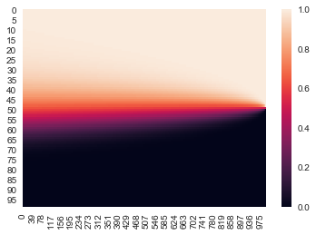

```python
sns.heatmap(Delta_matrix)
```

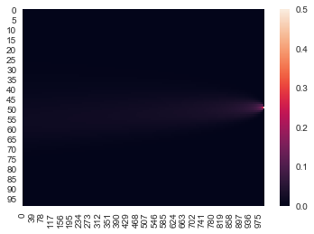

```python
sns.heatmap(Gamma_matrix)
```

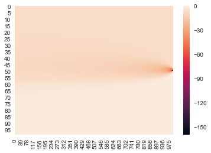

```python
sns.heatmap(Theta_matrix)
```

```python
xw.view(Theta_matrix)
```

## Problem 2 (20 points). Finite difference methods applied to market data. We will use here the algorithms implemented in Problem 1 to price European Call and Put options using market data, and compare these methods

```python
# I should say the problem 2  is totally a waste of time since it involves trivial repetition. Neither inspiring nor practical.
```

### (a) Download Option prices (you can use the Bloomberg Terminal, Yahoo! Finance, etc.) for an equity, for 3 different maturities (1 month, 2 months, and 3 months) and 10 strike prices. Use the same method from Homework 1 to calculate the implied volatility. Set the current short-term interest rate equal to the one from the day you downloaded the data.

```python
import datetime
date1 = datetime.datetime(2018,7,29)
# date2 = datetime.datetime(2018,6,18)
# date1_unix = int((date1 - datetime.datetime(1970,1,1)).total_seconds())
t_expired = datetime.datetime(2018,10,19)
three_months_unix = int((t_expired- datetime.datetime(1970,1,1)).total_seconds())
```

```python
import urllib
import json
from pandas.io.json import json_normalize
def get_option_yahoo(symbol):
    unix_time = three_months_unix # GMT: 2018,9,21 Friday 12 AM
    request = urllib.request.Request("https://query2.finance.yahoo.com/v7/finance/options/{}?date={}".format(symbol,unix_time))
    response = urllib.request.urlopen(request)
    option_data = response.read()
#     print(option_data["optionChain"]["result"])
    data = json.loads(option_data.decode("utf-8"))
    calls_data = data["optionChain"]["result"][0]["options"][0]["calls"][:]
    puts_data = data["optionChain"]["result"][0]["options"][0]["puts"][:]
    calls_df = pd.DataFrame(calls_data)
    puts_df = pd.DataFrame(puts_data)
    quote_series = pd.Series(data["optionChain"]["result"][0]["quote"])
    return calls_df, puts_df, quote_series
```

```python
unix_time = three_months_unix # GMT: 2018,9,21 Friday 12 AM
request = urllib.request.Request("https://query2.finance.yahoo.com/v7/finance/options/{}?date={}".format("spy",unix_time))
response = urllib.request.urlopen(request)
option_data = response.read()
```

```python
spy_call, spy_put, spy_quote = get_option_yahoo('SPY')
amzn_call, amzn_put, amzn_quote = get_option_yahoo('AMZN')
```

```python
spy_call.head()
```

|  | ask | bid | change | contractSize | contractSymbol | currency | expiration | impliedVolatility | inTheMoney | lastPrice | lastTradeDate | openInterest | percentChange | strike | volume |
| --- | --- | --- | --- | --- | --- | --- | --- | --- | --- | --- | --- | --- | --- | --- | --- |
| 0 | 181.64 | 181.28 | 1.000000 | REGULAR | SPY181019C00100000 | USD | 1539907200 | 0.895509 | True | 181.72 | 1532721599 | 1070 | 0.553342 | 100.0 | 98 |
| 1 | 176.79 | 176.18 | 6.740005 | REGULAR | SPY181019C00105000 | USD | 1539907200 | 0.695316 | True | 176.74 | 1532721599 | 33 | 3.964709 | 105.0 | 48 |
| 2 | 171.80 | 171.17 | 6.699997 | REGULAR | SPY181019C00110000 | USD | 1539907200 | 0.660160 | True | 171.76 | 1532721599 | 19 | 4.059128 | 110.0 | 48 |
| 3 | 166.20 | 163.00 | 162.970000 | REGULAR | SPY181019C00115000 | USD | 1539907200 | 0.000010 | True | 162.97 | 1531161122 | 102 | 100.000000 | 115.0 | 2 |
| 4 | 161.23 | 158.01 | 152.330000 | REGULAR | SPY181019C00120000 | USD | 1539907200 | 0.000010 | True | 152.33 | 1529937734 | 82 | 100.000000 | 120.0 | 2 |

```python
spy_put.head()
```

|  | ask | bid | change | contractSize | contractSymbol | currency | expiration | impliedVolatility | inTheMoney | lastPrice | lastTradeDate | openInterest | percentChange | strike | volume |
| --- | --- | --- | --- | --- | --- | --- | --- | --- | --- | --- | --- | --- | --- | --- | --- |
| 0 | 0.01 | 0.00 | 0.01 | REGULAR | SPY181019P00100000 | USD | 1539907200 | 0.640629 | False | 0.01 | 1531415083 | 744 | 100.0 | 100.0 | 220 |
| 1 | 0.02 | 0.00 | -0.01 | REGULAR | SPY181019P00105000 | USD | 1539907200 | 0.648441 | False | 0.01 | 1532104662 | 1 | -50.0 | 105.0 | 4377 |
| 2 | 0.02 | 0.01 | 0.03 | REGULAR | SPY181019P00110000 | USD | 1539907200 | 0.640629 | False | 0.03 | 1530800209 | 5 | 100.0 | 110.0 | 5 |
| 3 | 0.02 | 0.01 | 0.00 | REGULAR | SPY181019P00115000 | USD | 1539907200 | 0.609379 | False | 0.03 | 1531540728 | 1 | 0.0 | 115.0 | 1 |
| 4 | 0.03 | 0.02 | 0.02 | REGULAR | SPY181019P00120000 | USD | 1539907200 | 0.609379 | False | 0.02 | 1531769070 | 0 | 100.0 | 120.0 | 3 |

```python
spy_quote
```

```
language                                            en-US
region                                                 US
quoteType                                             ETF
quoteSourceName                             Delayed Quote
currency                                              USD
regularMarketPrice                                 281.46
regularMarketTime                              1532721602
regularMarketChange                                 -1.88
regularMarketOpen                                  283.71
regularMarketDayHigh                               283.82
regularMarketDayLow                                280.38
regularMarketVolume                              68736845
postMarketChangePercent                        -0.0355362
postMarketTime                                 1532735986
postMarketPrice                                    281.32
postMarketChange                                -0.100006
regularMarketChangePercent                      -0.663516
regularMarketDayRange                     280.38 - 283.82
regularMarketPreviousClose                         283.34
bid                                                     0
ask                                                     0
bidSize                                                 0
askSize                                                 0
messageBoardId                              finmb_6160262
fullExchangeName                                 NYSEArca
longName                             SPDR S&amp;P 500 ETF
financialCurrency                                     USD
averageDailyVolume3Month                         70022004
averageDailyVolume10Day                          67485057
fiftyTwoWeekLowChange                               39.63
fiftyTwoWeekLowChangePercent                     0.163875
fiftyTwoWeekRange                         241.83 - 286.63
fiftyTwoWeekHighChange                           -5.17001
fiftyTwoWeekHighChangePercent                  -0.0180372
fiftyTwoWeekLow                                    241.83
fiftyTwoWeekHigh                                   286.63
exchangeDataDelayedBy                                   0
fiftyDayAverageChange                             4.47351
fiftyDayAverageChangePercent                    0.0161506
twoHundredDayAverage                              272.417
twoHundredDayAverageChange                        9.04288
twoHundredDayAverageChangePercent                0.033195
marketCap                                    269352157184
sourceInterval                                         15
exchangeTimezoneName                     America/New_York
exchangeTimezoneShortName                             EDT
gmtOffSetMilliseconds                           -14400000
esgPopulated                                        False
tradeable                                            True
market                                          us_market
ytdReturn                                            2.59
trailingThreeMonthReturns                            3.55
trailingThreeMonthNavReturns                          3.4
sharesOutstanding                               956982016
fiftyDayAverage                                   276.986
exchange                                              PCX
priceHint                                               2
shortName                                    SPDR S&P 500
marketState                                        CLOSED
symbol                                                SPY
dtype: object
```

```python
date1_str = date1.strftime("%Y%m%d")
spy_call.to_csv("spy_call_{}.csv".format(date1_str))
spy_put.to_csv("spy_put_{}.csv".format(date1_str))
spy_quote.to_csv("spy_quote_{}.csv".format(date1_str))
amzn_call.to_csv("amzn_call_{}.csv".format(date1_str))
amzn_put.to_csv("amzn_put_{}.csv".format(date1_str))
amzn_quote.to_csv("amzn_quote_{}.csv".format(date1_str))
```

```python
r_three_months = 0.0195
```

```python
spy_quote_d1 = pd.Series.from_csv("spy_quote_{}.csv".format(date1_str))
spy_quote_d1
```

```
language                                            en-US
region                                                 US
quoteType                                             ETF
quoteSourceName                             Delayed Quote
currency                                              USD
regularMarketPrice                                 281.46
regularMarketTime                              1532721602
regularMarketChange                            -1.8800049
regularMarketOpen                                  283.71
regularMarketDayHigh                               283.82
regularMarketDayLow                                280.38
regularMarketVolume                              68736845
postMarketChangePercent                      -0.035536245
postMarketTime                                 1532735986
postMarketPrice                                    281.32
postMarketChange                               -0.1000061
regularMarketChangePercent                    -0.66351557
regularMarketDayRange                     280.38 - 283.82
regularMarketPreviousClose                         283.34
bid                                                   0.0
ask                                                   0.0
bidSize                                                 0
askSize                                                 0
messageBoardId                              finmb_6160262
fullExchangeName                                 NYSEArca
longName                             SPDR S&amp;P 500 ETF
financialCurrency                                     USD
averageDailyVolume3Month                         70022004
averageDailyVolume10Day                          67485057
fiftyTwoWeekLowChange                            39.62999
fiftyTwoWeekLowChangePercent                    0.1638754
fiftyTwoWeekRange                         241.83 - 286.63
fiftyTwoWeekHighChange                         -5.1700134
fiftyTwoWeekHighChangePercent                -0.018037237
fiftyTwoWeekLow                                    241.83
fiftyTwoWeekHigh                                   286.63
exchangeDataDelayedBy                                   0
fiftyDayAverageChange                           4.4735107
fiftyDayAverageChangePercent                  0.016150646
twoHundredDayAverage                             272.4171
twoHundredDayAverageChange                       9.042877
twoHundredDayAverageChangePercent             0.033194967
marketCap                                    269352157184
sourceInterval                                         15
exchangeTimezoneName                     America/New_York
exchangeTimezoneShortName                             EDT
gmtOffSetMilliseconds                           -14400000
esgPopulated                                        False
tradeable                                            True
market                                          us_market
ytdReturn                                            2.59
trailingThreeMonthReturns                            3.55
trailingThreeMonthNavReturns                          3.4
sharesOutstanding                               956982016
fiftyDayAverage                                 276.98648
exchange                                              PCX
priceHint                                               2
shortName                                    SPDR S&P 500
marketState                                        CLOSED
symbol                                                SPY
dtype: object
```

```python
spy_price = float(spy_quote_d1["regularMarketPrice"])
print("The underlyting price of SPY is {}".format(spy_price))
```

```
The underlyting price of SPY is 281.46
```

```python
spy_time = int(spy_quote_d1["regularMarketTime"])
timedelta=(datetime.datetime(2018,9,21)-datetime.datetime.fromtimestamp(spy_time))
time_to_maturity = timedelta.total_seconds()/3600/24/365
print("The time to maturity is {}y".format(time_to_maturity))
```

```
The time to maturity is 0.15159811009639776y
```

```python
import scipy as sp
import scipy.stats
import numpy as np

def BlackSholesPrice(S,K,T,r,sigma):
    d1 = (np.log(S/K) + r*T + sigma**2*T/2)/sigma/np.sqrt(T)
    d2 = d1 - sigma * np.sqrt(T)

    call_price = S*sp.stats.norm.cdf(d1) - np.exp(-r*T)*K*sp.stats.norm.cdf(d2)
    put_price = call_price + np.exp(-r*T)*K - S

    return call_price,put_price

def bisection(func,interval,tol):
    a,b = interval
    c = (a+b)/2.
    if func(a)*func(b)>0:
        print("warning: fun(a)*fun(b)>0")
#     func(a) - func(b)
    while(b-a>tol):
        if func(c) == 0:
            return c
        elif func(a)*func(c)<0:
            b=c
        else:
            a=c
        c = (a+b)/2.
    return c

def impliedvol(S,K,T,r,price,option_type):
    if(option_type=="c"):
        price_equation = lambda sigma: BlackSholesPrice(S,K,T,r,sigma)[0] - price
    elif(option_type=="p"):
        price_equation = lambda sigma: BlackSholesPrice(S,K,T,r,sigma)[1] - price

    imp_vol = bisection(price_equation,(-1,2),1e-6)
    return imp_vol
```

```python
# read d1 data
spy_call_d1 = pd.read_csv("spy_call_{}.csv".format(date1_str))
spy_put_d1 = pd.read_csv("spy_put_{}.csv".format(date1_str))
spy_quote_d1 = pd.Series.from_csv("spy_quote_{}.csv".format(date1_str))
amzn_call_d1 = pd.read_csv("amzn_call_{}.csv".format(date1_str))
amzn_put_d1 = pd.read_csv("amzn_put_{}.csv".format(date1_str))
amzn_quote_d1 = pd.Series.from_csv("amzn_quote_{}.csv".format(date1_str))
```

```python
def calculate_IV_for_quotes(option_df,quote_series,r,option_type):
    S = float(quote_series["regularMarketPrice"])
    t0 = spy_time = int(quote_series["regularMarketTime"])
    t1 = int(option_df["expiration"][0])
#     print(t1)
    T = (t1-t0)/3600/24/365

    def calc_iv(row):
        price = (float(row["bid"])+float(row["ask"]))/2
        K = float(row["strike"])
        return impliedvol(S,K,T,r,price,option_type)
    def calc_price(row):
        price = (float(row["bid"])+float(row["ask"]))/2
        return price

    option_df["my_iv"] = option_df.apply(calc_iv,axis=1)
    option_df["time_to_maturity"] = np.array([T]*len(option_df))
    option_df["days_count"] = np.array((t1-t0)/3600/24)
    option_df["average_price"] = option_df.apply(calc_price,axis=1)
    option_df["underlying_price"] = [S]*len(option_df)
    option_df["three_months_rate"] = [r]*len(option_df)
    return option_df
```

```python
spy_call_df = calculate_IV_for_quotes(spy_call_d1,spy_quote_d1,r_three_months,'c')
amzn_call_df = calculate_IV_for_quotes(amzn_call_d1,amzn_quote_d1,r_three_months,'c')
spy_put_df = calculate_IV_for_quotes(spy_put_d1,spy_quote_d1,r_three_months,'p')
amzn_put_df = calculate_IV_for_quotes(amzn_put_d1,amzn_quote_d1,r_three_months,'p')
```

```python
spy_put_concrete_df = spy_put_df.loc[:,["contractSymbol","ask","bid","average_price","underlying_price","strike","expiration","time_to_maturity","three_months_rate","impliedVolatility","my_iv"]]
amzn_put_concrete_df = amzn_put_df.loc[:,["contractSymbol","ask","bid","average_price","underlying_price","strike","expiration","time_to_maturity","three_months_rate","impliedVolatility","my_iv"]]
spy_call_concrete_df = spy_call_df.loc[:,["contractSymbol","ask","bid","average_price","underlying_price","strike","expiration","time_to_maturity","three_months_rate","impliedVolatility","my_iv"]]
amzn_call_concrete_df = amzn_call_df.loc[:,["contractSymbol","ask","bid","average_price","underlying_price","strike","expiration","time_to_maturity","three_months_rate","impliedVolatility","my_iv"]]
```

```python
spy_put_concrete_df.head()
```

|  | contractSymbol | ask | bid | average_price | underlying_price | strike | expiration | time_to_maturity | three_months_rate | impliedVolatility | my_iv |
| --- | --- | --- | --- | --- | --- | --- | --- | --- | --- | --- | --- |
| 0 | SPY181019P00100000 | 0.01 | 0.00 | 0.005 | 281.46 | 100.0 | 1539907200 | 0.227854 | 0.0195 | 0.640629 | 0.646307 |
| 1 | SPY181019P00105000 | 0.02 | 0.00 | 0.010 | 281.46 | 105.0 | 1539907200 | 0.227854 | 0.0195 | 0.648441 | 0.649804 |
| 2 | SPY181019P00110000 | 0.02 | 0.01 | 0.015 | 281.46 | 110.0 | 1539907200 | 0.227854 | 0.0195 | 0.640629 | 0.641004 |
| 3 | SPY181019P00115000 | 0.02 | 0.01 | 0.015 | 281.46 | 115.0 | 1539907200 | 0.227854 | 0.0195 | 0.609379 | 0.612086 |
| 4 | SPY181019P00120000 | 0.03 | 0.02 | 0.025 | 281.46 | 120.0 | 1539907200 | 0.227854 | 0.0195 | 0.609379 | 0.610675 |

```python
spy_call_concrete_df.head()
```

|  | contractSymbol | ask | bid | average_price | underlying_price | strike | expiration | time_to_maturity | three_months_rate | impliedVolatility | my_iv |
| --- | --- | --- | --- | --- | --- | --- | --- | --- | --- | --- | --- |
| 0 | SPY181019C00100000 | 181.64 | 181.28 | 181.460 | 281.46 | 100.0 | 1539907200 | 0.227854 | 0.0195 | 0.895509 | 1.192093e-07 |
| 1 | SPY181019C00105000 | 176.79 | 176.18 | 176.485 | 281.46 | 105.0 | 1539907200 | 0.227854 | 0.0195 | 0.695316 | 1.192093e-07 |
| 2 | SPY181019C00110000 | 171.80 | 171.17 | 171.485 | 281.46 | 110.0 | 1539907200 | 0.227854 | 0.0195 | 0.660160 | 1.192093e-07 |
| 3 | SPY181019C00115000 | 166.20 | 163.00 | 164.600 | 281.46 | 115.0 | 1539907200 | 0.227854 | 0.0195 | 0.000010 | 1.192093e-07 |
| 4 | SPY181019C00120000 | 161.23 | 158.01 | 159.620 | 281.46 | 120.0 | 1539907200 | 0.227854 | 0.0195 | 0.000010 | 1.192093e-07 |

### (b,c) Since these problems are full of repetition, and using finite difference method is time consuming, I take one entry as an example. Again, at this part we still can't use the theoretical formula to predetermine the dx and ds due to the limit of my computer. Then, I will repete the process in homework 1 and problem 1 in this assignment as following.

```python
# Wrap them altogether
def optionPrice_FDM2(S0=100, E=100, T=1, r=.06, sigma=0.25, isAmerican=False, isCall=True, NAS=100, NTS=1000,method="explicit",greeks=False):

    SIGMA = sigma  # Volatility
    Type = isCall  # Type of Option True=Call False=Put
    Ex = isAmerican  # Early Exercise True=Yes  False=No

    ds = 2 * E / NAS  # Asset Value Step Size
    dt = T / NTS  # Time Step Size

    #     NAS = 200  #Number of Asset Steps - Higher is more accurate, but more time consuming
    #     ds = 2 * E / NAS  #Asset Value Step Size
    #     dt = (0.9/NAS/NAS/SIGMA/SIGMA)  #Time Step Size
    #     NTS = int(T / dt) + 1  #Number of Time Steps
    #     dt = T / NTS #Time Step Size

    print("Asset Step Size %.2f Time Step Size %.2f Number of Time Steps %.2f Number of Asset Steps %.2f" % (
    ds, dt, NTS, NAS))
    # Run BSM Calculation for values and greeks
#     S0 = 100  # Current Value
    R = r
    # BSM function call and output assignment
    call_value, delta_call, gamma_call, theta_call, rho_call, vega_call, put_value, delta_put, gamma_put, theta_put, rho_put, vega_put = bsm_option_value(
        S0, E, T, R, SIGMA)

    if Type == False:
        BSM_val = put_value
    if Type == True:
        BSM_val = call_value
    print("Black-Scholes value: {}".format(BSM_val))
    if(method=="black-sholes"):
        return BSM_val

    # Setup Empty numpy Arrays
    value_matrix = np.zeros((int(NAS + 1), int(NTS)))
    asset_price = np.arange(NAS * ds, 0 - 1e-6, -ds)
    Delta_matrix = np.zeros((int(NAS-1),int(NTS-1)))
    Gamma_matrix = np.zeros((int(NAS-1),int(NTS-1)))
    Theta_matrix = np.zeros((int(NAS-1),int(NTS-1)))
    # print(asset_price.shape)
    if method == "explicit":

        # Evaluate Terminal Value for Calls or Puts
        if Type == True:
            value_matrix[:, -1] = np.maximum(asset_price - E, 0)
        else:
            value_matrix[:, -1] = np.maximum(E - asset_price, 0)

        # Set Lower Boundry in Grid
        for x in range(1, NTS):
            value_matrix[-1, -x - 1] = value_matrix[-1, -x] * math.exp(-r * dt)

        # Set Mid and Ceiling Values in Grid
        for x in range(1, int(NTS)):

            for y in range(1, int(NAS)):
                # Evaluate Option Greeks
                Delta = (value_matrix[y - 1, -x] - value_matrix[y + 1, -x]) / 2 / ds
                Gamma = (value_matrix[y - 1, -x] - (2 * value_matrix[y, -x]) + value_matrix[y + 1, -x]) / ds / ds
                Theta = (-.5 * SIGMA ** 2 * asset_price[y] ** 2 * Gamma) - (r * asset_price[y] * Delta) + (
                            r * value_matrix[y, -x])
                Delta_matrix[y-1,-x] = Delta
                Gamma_matrix[y-1,-x] = Gamma
                Theta_matrix[y-1,-x] = Theta
                # Set Mid Values
                value_matrix[y, -x - 1] = value_matrix[y, -x] - Theta * dt
                if Ex == True:
                    value_matrix[y, -x - 1] = np.maximum(value_matrix[y, -x - 1], value_matrix[y, -1])

                # Set Ceiling Value
                value_matrix[0, -x - 1] = 2 * value_matrix[1, -x - 1] - value_matrix[2, -x - 1]
    elif method=="implicit":
        # Evaluate Terminal Value for Calls or Puts
        if Type == True:
            value_matrix[:, -1] = np.maximum(asset_price - E, 0)
            # Set Lower Boundry in Grid
            for x in range(1, NTS):
                value_matrix[-1, -x - 1] = 0
                value_matrix[0, -x - 1] = asset_price[0] - E * math.exp(-r * dt * x)
        else:
            value_matrix[:, -1] = np.maximum(E - asset_price, 0)
            # Set Lower Boundry in Grid
            for x in range(1, NTS):
                value_matrix[-1, -x - 1] = value_matrix[-1, -x] * math.exp(-r * dt)
                value_matrix[0, -x - 1] = 0
        a = lambda x: (r * x / 2 / ds - (SIGMA * x) ** 2 / 2 / ds ** 2) * dt
        b = lambda x: 1 + r * dt + (SIGMA * x) ** 2 * dt / ds ** 2
        c = lambda x: -(r * x / 2 / ds + (SIGMA * x) ** 2 / 2 / ds ** 2) * dt
        a_entries = a(asset_price[1:-2])
        b_entries = b(asset_price[1:-1])
        c_entries = c(asset_price[2:-1])
        A = np.diag(a_entries, 1) + np.diag(b_entries) + np.diag(c_entries, -1)
        # Set Mid and Ceiling Values in Grid
        for x in range(1, int(NTS)):
            d = value_matrix[1:-1, -x]
            d[0] -= c(asset_price[1]) * value_matrix[0, -x - 1]
            d[-1] -= a(asset_price[-2]) * value_matrix[-1, -x - 1]
            value_matrix[1:-1, -x - 1] = np.linalg.solve(A, d)
    elif method == "crank-nicolson":
        # Crank-Nicolson Scheme
        if Type == True:
            value_matrix[:, -1] = np.maximum(asset_price - E, 0)
            # Set Lower Boundry in Grid
            for x in range(1, NTS):
                value_matrix[-1, -x - 1] = 0
                value_matrix[0, -x - 1] = asset_price[0]
        else:
            value_matrix[:, -1] = np.maximum(E - asset_price, 0)
            # Set Lower Boundry in Grid
            for x in range(1, NTS):
                value_matrix[-1, -x - 1] = value_matrix[-1, -x] * math.exp(-r * dt)
                value_matrix[0, -x - 1] = 0
        #     xw.view(value_matrix)
        a1 = lambda x: (-r * x / 4 / ds + (SIGMA * x) ** 2 / 4 / ds ** 2)
        b1 = lambda x: -(1 / dt + r / 2 + (SIGMA * x) ** 2 / 2 / ds ** 2)
        c1 = lambda x: (r * x / 4 / ds + (SIGMA * x) ** 2 / 4 / ds ** 2)
        a2 = a1
        b2 = lambda x: -(-1 / dt + r / 2 + (SIGMA * x) ** 2 / 2 / ds ** 2)
        c2 = c1

        a1_entries = a1(asset_price[1:-2])
        b1_entries = b1(asset_price[1:-1])
        c1_entries = c1(asset_price[2:-1])

        A = np.diag(a1_entries, 1) + np.diag(b1_entries) + np.diag(c1_entries, -1)
        # Set Mid and Ceiling Values in Grid
        for x in range(1, int(NTS)):
            d = -(value_matrix[0:-2, -x] * a2(asset_price[1:-1]) + value_matrix[1:-1, -x] * b2(asset_price[1:-1])
                  + value_matrix[2:, -x] * c2(asset_price[1:-1]))
            d[0] -= c1(asset_price[1]) * value_matrix[0, -x - 1]
            d[-1] -= a1(asset_price[-2]) * value_matrix[-1, -x - 1]
            value_matrix[1:-1, -x - 1] = np.linalg.solve(A, d)
    elif method == "black-scholes":
        print("***********{}".format(BSM_val))
        return BSM_val

    # Option Valuation Profile in pandas - Index is Strike Price, column 0 is the option price
    value_df = pd.DataFrame(value_matrix)
    value_df = value_df.set_index(asset_price)

    # Export Value Grid to Excel via xlWings
    # xw.view(value_df)



#     # Finite Differences Method Value at S0
#     fd_value = value_df.ix[S0, 1]
#     print("finite difference value: {}".format(fd_value))

#     # Difference
#     diff = BSM_val - fd_value
#     print("Nominal Difference is %.4f" % diff)

#     pct_diff = abs(diff / BSM_val)
#     print("Percent Difference is {percent:.4%}".format(percent=pct_diff))
    if greeks==True:
        return value_df,Delta_matrix,Gamma_matrix,Theta_matrix
    return value_df
```

```python
spy_put_concrete_df.iloc[69]
```

```
contractSymbol       SPY181019P00281000
ask                                5.81
bid                                5.74
average_price                     5.775
underlying_price                 281.46
strike                              281
expiration                   1539907200
time_to_maturity               0.227854
three_months_rate                0.0195
impliedVolatility              0.112924
my_iv                          0.123395
Name: 69, dtype: object
```

```python
spy_put_sample = spy_put_concrete_df.iloc[69]
```

```python
average_price = spy_put_sample["average_price"]
underlying_price = spy_put_sample["underlying_price"]
K = spy_put_sample["strike"]
T = spy_put_sample["time_to_maturity"]
r = spy_put_sample["three_months_rate"]
sigma = spy_put_sample["my_iv"]
```

```python
value_df,Delta_matrix,Gamma_matrix,Theta_matrix = optionPrice_FDM2(S0=281.0,E=K,T=T,r=r,sigma=sigma,isCall=False,greeks=True)
```

```
Asset Step Size 5.62 Time Step Size 0.00 Number of Time Steps 1000.00 Number of Asset Steps 100.00
Black-Scholes value: 5.98325255934563
```

```python
value_df.shape,Delta_matrix.shape
```

```
((101, 1000), (99, 999))
```

```python
# Since we cannot obtain the arbitrary point in the finite difference grid, we can select the nearest neighbor as an substitution
value_df.iloc[50:51]
```

|  | 0 | 1 | 2 | 3 | 4 | 5 | 6 | 7 | 8 | 9 | ... | 990 | 991 | 992 | 993 | 994 | 995 | 996 | 997 | 998 | 999 |
| --- | --- | --- | --- | --- | --- | --- | --- | --- | --- | --- | --- | --- | --- | --- | --- | --- | --- | --- | --- | --- | --- |
| 281.0 | 5.884062 | 5.881324 | 5.878584 | 5.875843 | 5.873099 | 5.870355 | 5.867608 | 5.86486 | 5.862109 | 5.859358 | ... | 0.206349 | 0.184217 | 0.161892 | 0.139372 | 0.116654 | 0.093735 | 0.070613 | 0.047285 | 0.023748 | 2.273737e-13 |

1 rows × 1000 columns

```python
# Delata Gamma and Theta are function with respect to time and stock price, saved as the following matrices
Delta_matrix
```

```
array([[-1.88563255e-24, -1.82055432e-24, -1.75763755e-24, ...,
         0.00000000e+00,  0.00000000e+00,  0.00000000e+00],
       [-3.93253263e-24, -3.79956321e-24, -3.67091723e-24, ...,
         0.00000000e+00,  0.00000000e+00,  0.00000000e+00],
       [-1.45676852e-23, -1.40879241e-23, -1.36233370e-23, ...,
         0.00000000e+00,  0.00000000e+00,  0.00000000e+00],
       ...,
       [-1.00000000e+00, -1.00000000e+00, -1.00000000e+00, ...,
        -1.00000000e+00, -1.00000000e+00, -1.00000000e+00],
       [-1.00000000e+00, -1.00000000e+00, -1.00000000e+00, ...,
        -1.00000000e+00, -1.00000000e+00, -1.00000000e+00],
       [-1.00000025e+00, -1.00000024e+00, -1.00000024e+00, ...,
        -1.00000000e+00, -1.00000000e+00, -1.00000000e+00]])
```

```python
Gamma_matrix
```

```
array([[ 0.00000000e+00,  0.00000000e+00,  0.00000000e+00, ...,
         0.00000000e+00,  0.00000000e+00,  0.00000000e+00],
       [ 7.28434192e-25,  7.04273627e-25,  6.80882449e-25, ...,
         0.00000000e+00,  0.00000000e+00,  0.00000000e+00],
       [ 3.05631761e-24,  2.95706477e-24,  2.86090394e-24, ...,
         0.00000000e+00,  0.00000000e+00,  0.00000000e+00],
       ...,
       [-1.43978467e-14, -1.43978467e-14, -1.43978467e-14, ...,
         0.00000000e+00,  0.00000000e+00,  0.00000000e+00],
       [-2.11252406e-11, -2.10838468e-11, -2.10406533e-11, ...,
         0.00000000e+00,  0.00000000e+00,  0.00000000e+00],
       [ 8.72975067e-08,  8.72103800e-08,  8.71232514e-08, ...,
         1.75635733e-10,  8.78178665e-11,  0.00000000e+00]])
```

```python
Theta_matrix
```

```
array([[ 2.04555520e-23,  1.97495794e-23,  1.90670543e-23, ...,
         0.00000000e+00,  0.00000000e+00,  0.00000000e+00],
       [-1.63976053e-21, -1.58540077e-21, -1.53277113e-21, ...,
         0.00000000e+00,  0.00000000e+00,  0.00000000e+00],
       [-6.75904022e-21, -6.53961493e-21, -6.32702289e-21, ...,
         0.00000000e+00,  0.00000000e+00,  0.00000000e+00],
       ...,
       [ 5.45525619e+00,  5.45528043e+00,  5.45530467e+00, ...,
         5.47945131e+00,  5.47947565e+00,  5.47950000e+00],
       [ 5.45525619e+00,  5.45528043e+00,  5.45530467e+00, ...,
         5.47945131e+00,  5.47947565e+00,  5.47950000e+00],
       [ 5.45525620e+00,  5.45528044e+00,  5.45530468e+00, ...,
         5.47945131e+00,  5.47947565e+00,  5.47950000e+00]])
```

### (d) Still, we take the sample entry as an example to illustrate the performance of FDM comparing to BS formula

```python
value_df1= optionPrice_FDM2(S0=281.0,E=K,T=T,r=r,sigma=sigma,isCall=False,method="explicit")
value_df2= optionPrice_FDM2(S0=281.0,E=K,T=T,r=r,sigma=sigma,isCall=False,method="implicit")
value_df3= optionPrice_FDM2(S0=281.0,E=K,T=T,r=r,sigma=sigma,isCall=False,method="crank-nicolson")
bs_value= optionPrice_FDM2(S0=281.0,E=K,T=T,r=r,sigma=sigma,isCall=False,method="black-sholes")
```

```
Asset Step Size 5.62 Time Step Size 0.00 Number of Time Steps 1000.00 Number of Asset Steps 100.00
Black-Scholes value: 5.98325255934563
Asset Step Size 5.62 Time Step Size 0.00 Number of Time Steps 1000.00 Number of Asset Steps 100.00
Black-Scholes value: 5.98325255934563
Asset Step Size 5.62 Time Step Size 0.00 Number of Time Steps 1000.00 Number of Asset Steps 100.00
Black-Scholes value: 5.98325255934563
Asset Step Size 5.62 Time Step Size 0.00 Number of Time Steps 1000.00 Number of Asset Steps 100.00
Black-Scholes value: 5.98325255934563
```

```python
optionPrice_FDM2(S0=281.0,E=K,T=T,r=r,sigma=sigma,isCall=False,method="black-sholes")
```

```
Asset Step Size 5.62 Time Step Size 0.00 Number of Time Steps 1000.00 Number of Asset Steps 100.00
Black-Scholes value: 5.98325255934563
```

```
5.98325255934563
```

```python
explicit_value = value_df1.iloc[50,0]
implicit_value = value_df2.iloc[50,0]
cn_value = value_df3.iloc[50,0]
```

```python
explicit_value,implicit_value,cn_value,bs_value
```

```
(5.88406162857724, 5.882334143664595, 6.472638141660149, 5.98325255934563)
```

### For 3D Ploting, we draw prices versus strike and time to maturity. To avoid confusion, I'm not goting to plot bid and ask as well as other finite difference method's price as they are all similar to the average contract price.

```python
one_month_expired = datetime.datetime(2018,8,24)
two_months_expired = datetime.datetime(2018,9,21)
three_months_expired = datetime.datetime(2018,10,19)
```

```python
def get_option_yahoo2(symbol,t_expired):
    unix_expiration = int((t_expired- datetime.datetime(1970,1,1)).total_seconds())
    request = urllib.request.Request("https://query2.finance.yahoo.com/v7/finance/options/{}?date={}".format(symbol,unix_expiration))
    response = urllib.request.urlopen(request)
    option_data = response.read()
    data = json.loads(option_data.decode("utf-8"))
    calls_data = data["optionChain"]["result"][0]["options"][0]["calls"][:]
    puts_data = data["optionChain"]["result"][0]["options"][0]["puts"][:]
    calls_df = pd.DataFrame(calls_data)
    puts_df = pd.DataFrame(puts_data)
    quote_series = pd.Series(data["optionChain"]["result"][0]["quote"])
    return calls_df, puts_df, quote_series
```

```python
calls_df1, puts_df1, quote_series1 = get_option_yahoo2("spy",one_month_expired)
```

```python
calls_df2, puts_df2, quote_series2 = get_option_yahoo2("spy",two_months_expired)
```

```python
calls_df3, puts_df3, quote_series3 = get_option_yahoo2("spy",three_months_expired)
```

```python
put_df1
```

[output not shown]

```python
put_df3 = calculate_IV_for_quotes(puts_df3,quote_series3,r_three_months,'p').loc[:,["contractSymbol","ask","bid","average_price","underlying_price","strike","expiration","time_to_maturity","three_months_rate","impliedVolatility","my_iv"]]
put_df2 = calculate_IV_for_quotes(puts_df2,quote_series2,r_three_months,'p').loc[:,["contractSymbol","ask","bid","average_price","underlying_price","strike","expiration","time_to_maturity","three_months_rate","impliedVolatility","my_iv"]]
put_df1 = calculate_IV_for_quotes(puts_df1,quote_series1,r_three_months,'p').loc[:,["contractSymbol","ask","bid","average_price","underlying_price","strike","expiration","time_to_maturity","three_months_rate","impliedVolatility","my_iv"]]

call_df3 = calculate_IV_for_quotes(calls_df3,quote_series3,r_three_months,'c').loc[:,["contractSymbol","ask","bid","average_price","underlying_price","strike","expiration","time_to_maturity","three_months_rate","impliedVolatility","my_iv"]]
call_df2 = calculate_IV_for_quotes(calls_df2,quote_series2,r_three_months,'c').loc[:,["contractSymbol","ask","bid","average_price","underlying_price","strike","expiration","time_to_maturity","three_months_rate","impliedVolatility","my_iv"]]
call_df1 = calculate_IV_for_quotes(calls_df1,quote_series1,r_three_months,'c').loc[:,["contractSymbol","ask","bid","average_price","underlying_price","strike","expiration","time_to_maturity","three_months_rate","impliedVolatility","my_iv"]]
```

```python
calls_df = pd.concat((call_df1,call_df2,call_df3),axis=0)
puts_df = pd.concat((put_df1,put_df2,put_df3),axis=0)
```

```python
call_strikeline = calls_df.strike
call_timeline = calls_df["time_to_maturity"]
call_prices = calls_df.average_price

put_strikeline = puts_df.strike
put_timeline = puts_df["time_to_maturity"]
put_prices = puts_df.average_price
```

```python
import matplotlib.pyplot as plt
from mpl_toolkits.mplot3d import Axes3D
from matplotlib import cm
```

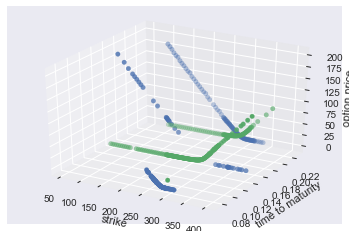

```python
fig = plt.figure()
ax = fig.gca(projection='3d')

ax.scatter3D(call_strikeline,call_timeline,call_prices)
ax.scatter3D(put_strikeline,put_timeline,put_prices)
ax.set_xlabel('strike')
ax.set_ylabel('time to maturity')
ax.set_zlabel('option price')
plt.show()
```

### Conclusion

- When the contract is near to expiration, the shape of price corresponding to strike is similar to it's payoff.
- There is fewer choice in strike of the one month contract, people tend to buy the ATM contract for short period hedging

## Problem 3 (30 points). Design an EFD scheme We know that an option price under a certain stochastic model satisfies the following PDE:

\begin{align} \frac{\partial{u}}{\partial{t}} (x,t) + \mu(x,t) \frac{\partial{u}}{\partial{x}}(x,t) + \frac{1}{2} \sigma^2 (x,t) \frac{\partial^2{u}}{\partial{x}^2} (x,t) - r(x,t) u(x,t) = 0 \end{align}

where

\begin{align} \mu(x,t) &= 2cos(x)\\ \sigma(x,t) &= 0.4x^{\frac{3}{4}}\\ r(x,t) &= r \end{align}

The problem can hardly solved by explicit formula unlike geometric brownian motion, however, can be directly compatible for Monte-Carlo simulation and finite difference method.

```python
def exoticOptionPrice_explicit_FDM(S0=100,E=100,T=1,r=.06,sigma=0.25,isAmerican=False,isCall=True,NAS=100,NTS=400):

    SIGMA = sigma  #Volatility
    Type = isCall   #Type of Option True=Call False=Put
    Ex = isAmerican #Early Exercise True=Yes  False=No
    ds = 2 * E / NAS  #Asset Value Step Size
#     dt = (1/NAS/NAS/SIGMA/SIGMA)  #Time Step Size
#     NTS = int(T / dt) + 1  #Number of Time Steps
    dt = T / NTS #Time Step Size

    print("Asset Step Size %.2f Time Step Size %.2f Number of Time Steps %.2f Number of Asset Steps %.2f" %(ds, dt, NTS, NAS))
    # Run BSM Calculation for values and greeks
    R = r
    # BSM function call and output assignment
    call_value, delta_call, gamma_call, theta_call, rho_call, vega_call, put_value, delta_put, gamma_put, theta_put, rho_put, vega_put = bsm_option_value(
        S0, E, T, R, SIGMA)

    if Type == False:
        BSM_val = put_value
    if Type == True:
        BSM_val = call_value
    print("Black-Scholes value: {}".format(BSM_val))
    #Setup Empty numpy Arrays
    value_matrix = np.zeros((int(NAS+1), int(NTS)))
    asset_price = np.arange(NAS*ds,0-1e-6,-ds)
    Delta_matrix = np.zeros((int(NAS-1),int(NTS-1)))
    Gamma_matrix = np.zeros((int(NAS-1),int(NTS-1)))
    Theta_matrix = np.zeros((int(NAS-1),int(NTS-1)))

    # print(asset_price.shape)


    #Evaluate Terminal Value for Calls or Puts
    if Type == True:
        value_matrix[:,-1]= np.maximum(asset_price - E,0)
    else:
        value_matrix[:,-1]= np.maximum(E - asset_price,0)

    #Set Lower Boundry in Grid
    for x in range(1,NTS):
        value_matrix[-1,-x-1] = value_matrix[-1,-x]* math.exp(-r*dt)

    #Set Mid and Ceiling Values in Grid
    for x in range(1,int(NTS)):
        for y in range(1,int(NAS)):
            #Evaluate Option Greeks
            Delta = (value_matrix[y-1,-x] - value_matrix[y+1,-x]) / 2 / ds
            Gamma = (value_matrix[y-1,-x] - (2 * value_matrix[y,-x]) + value_matrix[y+1,-x]) / ds / ds
            Theta = -(0.2*asset_price[y]**(3/2) * Gamma) - (2*np.cos(asset_price[y]) * Delta) + (r * value_matrix[y,-x])
            Delta_matrix[y-1,-x] = Delta
            Gamma_matrix[y-1,-x] = Gamma
            Theta_matrix[y-1,-x] = Theta
            #Set Mid Values
            value_matrix[y,-x-1] = value_matrix[y,-x] - Theta * dt
            if Ex == True:
                value_matrix[y,-x-1] = np.maximum(value_matrix[y,-x-1], value_matrix[y,-1])
            #Set Ceiling Value
            value_matrix[0,-x-1] = 2 * value_matrix[1,-x-1] - value_matrix[2,-x-1]


    #Option Valuation Profile in pandas - Index is Strike Price, column 0 is the option price
    value_df = pd.DataFrame(value_matrix)
    value_df = value_df.set_index(asset_price)

    #Export Value Grid to Excel via xlWings
    # xw.view(value_df)



    #Finite Differences Method Value at S0
    fd_value = value_df.ix[S0,1]
    print("finite difference value: {}".format(fd_value))

    return fd_value,value_df,Delta_matrix,Gamma_matrix,Theta_matrix
```

```python
fd_value1,value_df1,Delta_matrix1,Gamma_matrix1,Theta_matrix1 = optionPrice_FDM2(greeks=True)
print(fd_value1)
xw.view(value_df1)
```

[output not shown]

```python
fd_value1,value_df1,Delta_matrix1,Gamma_matrix1,Theta_matrix1 = optionPrice_FDM(NAS=100,NTS=1000,greeks=True)
fd_value2,value_df2,Delta_matrix2,Gamma_matrix2,Theta_matrix2 = exoticOptionPrice_explicit_FDM(NAS=100,NTS=1000)
```

```
Asset Step Size 2.00 Time Step Size 0.00 Number of Time Steps 1000.00 Number of Asset Steps 100.00
Black-Scholes value: 12.845046161722756
```

```
finite difference value: 12.82309414924826
Nominal Difference is 0.0220
Percent Difference is 0.1709%
Asset Step Size 2.00 Time Step Size 0.00 Number of Time Steps 1000.00 Number of Asset Steps 100.00
Black-Scholes value: 12.845046161722756
finite difference value: 7.493806387828682
```

```python
fd_value1,fd_value2
```

```
(12.82309414924826, 7.493806387828682)
```

```python
xw.view(value_df1)
xw.view(value_df2)
```

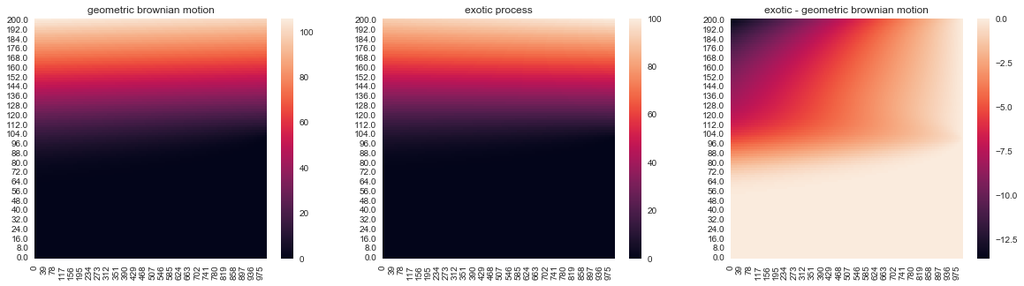

```python
plt.figure(figsize=(20,5))
plt.subplot(1,3,1)
sns.heatmap(value_df1)
plt.title("geometric brownian motion")
plt.subplot(1,3,2)
sns.heatmap(value_df2)
plt.title("exotic process")
plt.subplot(1,3,3)
sns.heatmap(value_df2 - value_df1)
plt.title("exotic - geometric brownian motion")
plt.show()
```

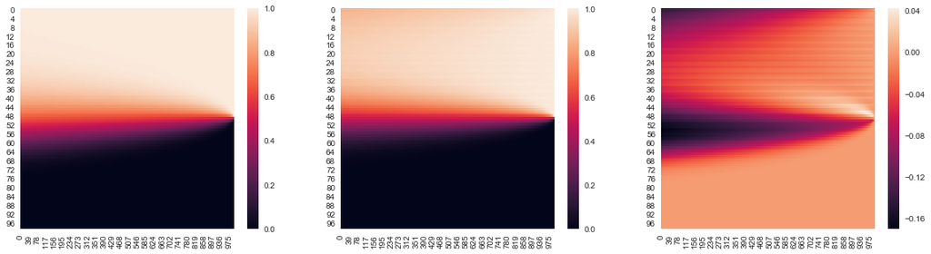

```python
plt.figure(figsize=(20,5))
plt.subplot(1,3,1)
sns.heatmap(Delta_matrix1)
plt.subplot(1,3,2)
sns.heatmap(Delta_matrix2)
plt.subplot(1,3,3)
sns.heatmap(Delta_matrix2 - Delta_matrix1)
```

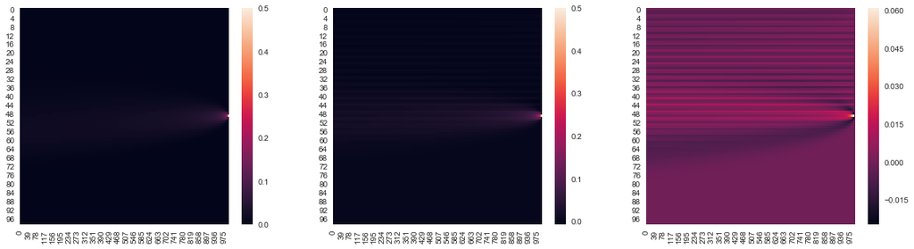

```python
plt.figure(figsize=(20,5))
plt.subplot(1,3,1)
sns.heatmap(Gamma_matrix1)
plt.subplot(1,3,2)
sns.heatmap(Gamma_matrix2)
plt.subplot(1,3,3)
sns.heatmap(Gamma_matrix2 -Gamma_matrix1)
```

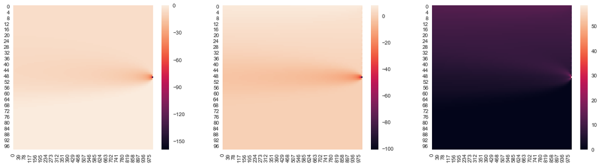

```python
plt.figure(figsize=(20,5))
plt.subplot(1,3,1)
sns.heatmap(Theta_matrix1)
plt.subplot(1,3,2)
sns.heatmap(Theta_matrix2)
plt.subplot(1,3,3)
sns.heatmap(Theta_matrix2 -Theta_matrix1)
```